# Data Transformation & Visualization in Python: numpy, pandas, matplotlib, and seaborn

# Introduction to Pandas

Pandas is a great tool for working with data in Python. The main object in Pandas you will use is the **DataFrame**. It has several advantages over numpy ndarrays:

1. Allows mixed-types
2. Label-based row-column indices
3. Easy database-like operations (merge, join, groupby, sort, etc...)

**If pandas is so great, why'd we just learn about numpy?**

- many of the same thigns work on numpy dataframes and pandas arrays
- pandas actually uses numpy under the hood
- many libraries expect numpy arrays (but easy to cast from pandas to numpy)

```python
import pandas as pd  # Pandas is usually abbreviated this way in python
```

To play around with Pandas, first let's read in some data from file.

In the nycflights13 folder, we have a set of files with data on all the flights that departed NYC airports in 2013.

```python
# Read in data from a tab-delimited text-file
planes = pd.read_table("../data/nycflights13/planes.txt")

# Pandas also has read_excel, read_csv, read_json, read_sql and others
```

```python
# What's this 'plane' variable have in it?
print(type(planes))
```

```
<class 'pandas.core.frame.DataFrame'>
```

```python
planes
```

|  | tailnum | year | type | manufacturer | model | engines | seats | speed | engine |
| --- | --- | --- | --- | --- | --- | --- | --- | --- | --- |
| 0 | N10156 | 2004.0 | Fixed wing multi engine | EMBRAER | EMB-145XR | 2 | 55 | NaN | Turbo-fan |
| 1 | N102UW | 1998.0 | Fixed wing multi engine | AIRBUS INDUSTRIE | A320-214 | 2 | 182 | NaN | Turbo-fan |
| 2 | N103US | 1999.0 | Fixed wing multi engine | AIRBUS INDUSTRIE | A320-214 | 2 | 182 | NaN | Turbo-fan |
| 3 | N104UW | 1999.0 | Fixed wing multi engine | AIRBUS INDUSTRIE | A320-214 | 2 | 182 | NaN | Turbo-fan |
| 4 | N10575 | 2002.0 | Fixed wing multi engine | EMBRAER | EMB-145LR | 2 | 55 | NaN | Turbo-fan |
| 5 | N105UW | 1999.0 | Fixed wing multi engine | AIRBUS INDUSTRIE | A320-214 | 2 | 182 | NaN | Turbo-fan |
| 6 | N107US | 1999.0 | Fixed wing multi engine | AIRBUS INDUSTRIE | A320-214 | 2 | 182 | NaN | Turbo-fan |
| 7 | N108UW | 1999.0 | Fixed wing multi engine | AIRBUS INDUSTRIE | A320-214 | 2 | 182 | NaN | Turbo-fan |
| 8 | N109UW | 1999.0 | Fixed wing multi engine | AIRBUS INDUSTRIE | A320-214 | 2 | 182 | NaN | Turbo-fan |
| 9 | N110UW | 1999.0 | Fixed wing multi engine | AIRBUS INDUSTRIE | A320-214 | 2 | 182 | NaN | Turbo-fan |
| 10 | N11106 | 2002.0 | Fixed wing multi engine | EMBRAER | EMB-145XR | 2 | 55 | NaN | Turbo-fan |
| 11 | N11107 | 2002.0 | Fixed wing multi engine | EMBRAER | EMB-145XR | 2 | 55 | NaN | Turbo-fan |
| 12 | N11109 | 2002.0 | Fixed wing multi engine | EMBRAER | EMB-145XR | 2 | 55 | NaN | Turbo-fan |
| 13 | N11113 | 2002.0 | Fixed wing multi engine | EMBRAER | EMB-145XR | 2 | 55 | NaN | Turbo-fan |
| 14 | N11119 | 2002.0 | Fixed wing multi engine | EMBRAER | EMB-145XR | 2 | 55 | NaN | Turbo-fan |
| 15 | N11121 | 2003.0 | Fixed wing multi engine | EMBRAER | EMB-145XR | 2 | 55 | NaN | Turbo-fan |
| 16 | N11127 | 2003.0 | Fixed wing multi engine | EMBRAER | EMB-145XR | 2 | 55 | NaN | Turbo-fan |
| 17 | N11137 | 2003.0 | Fixed wing multi engine | EMBRAER | EMB-145XR | 2 | 55 | NaN | Turbo-fan |
| 18 | N11140 | 2003.0 | Fixed wing multi engine | EMBRAER | EMB-145XR | 2 | 55 | NaN | Turbo-fan |
| 19 | N11150 | 2003.0 | Fixed wing multi engine | EMBRAER | EMB-145XR | 2 | 55 | NaN | Turbo-fan |
| 20 | N11155 | 2004.0 | Fixed wing multi engine | EMBRAER | EMB-145XR | 2 | 55 | NaN | Turbo-fan |
| 21 | N11164 | 2004.0 | Fixed wing multi engine | EMBRAER | EMB-145XR | 2 | 55 | NaN | Turbo-fan |
| 22 | N11165 | 2004.0 | Fixed wing multi engine | EMBRAER | EMB-145XR | 2 | 55 | NaN | Turbo-fan |
| 23 | N11176 | 2004.0 | Fixed wing multi engine | EMBRAER | EMB-145XR | 2 | 55 | NaN | Turbo-fan |
| 24 | N11181 | 2005.0 | Fixed wing multi engine | EMBRAER | EMB-145XR | 2 | 55 | NaN | Turbo-fan |
| 25 | N11184 | 2005.0 | Fixed wing multi engine | EMBRAER | EMB-145XR | 2 | 55 | NaN | Turbo-fan |
| 26 | N11187 | 2005.0 | Fixed wing multi engine | EMBRAER | EMB-145XR | 2 | 55 | NaN | Turbo-fan |
| 27 | N11189 | 2005.0 | Fixed wing multi engine | EMBRAER | EMB-145XR | 2 | 55 | NaN | Turbo-fan |
| 28 | N11191 | 2005.0 | Fixed wing multi engine | EMBRAER | EMB-145XR | 2 | 55 | NaN | Turbo-fan |
| 29 | N11192 | 2005.0 | Fixed wing multi engine | EMBRAER | EMB-145XR | 2 | 55 | NaN | Turbo-fan |
| ... | ... | ... | ... | ... | ... | ... | ... | ... | ... |
| 3292 | N984DL | 1991.0 | Fixed wing multi engine | MCDONNELL DOUGLAS AIRCRAFT CO | MD-88 | 2 | 142 | NaN | Turbo-fan |
| 3293 | N985AT | 2001.0 | Fixed wing multi engine | BOEING | 717-200 | 2 | 100 | NaN | Turbo-fan |
| 3294 | N985DL | 1991.0 | Fixed wing multi engine | MCDONNELL DOUGLAS AIRCRAFT CO | MD-88 | 2 | 142 | NaN | Turbo-fan |
| 3295 | N986AT | 2001.0 | Fixed wing multi engine | BOEING | 717-200 | 2 | 100 | NaN | Turbo-fan |
| 3296 | N986DL | 1991.0 | Fixed wing multi engine | MCDONNELL DOUGLAS AIRCRAFT CO | MD-88 | 2 | 142 | NaN | Turbo-fan |
| 3297 | N987AT | 2001.0 | Fixed wing multi engine | BOEING | 717-200 | 2 | 100 | NaN | Turbo-fan |
| 3298 | N987DL | 1991.0 | Fixed wing multi engine | MCDONNELL DOUGLAS AIRCRAFT CO | MD-88 | 2 | 142 | NaN | Turbo-fan |
| 3299 | N988AT | 2001.0 | Fixed wing multi engine | BOEING | 717-200 | 2 | 100 | NaN | Turbo-fan |
| 3300 | N988DL | 1991.0 | Fixed wing multi engine | MCDONNELL DOUGLAS AIRCRAFT CO | MD-88 | 2 | 142 | NaN | Turbo-fan |
| 3301 | N989AT | 2001.0 | Fixed wing multi engine | BOEING | 717-200 | 2 | 100 | NaN | Turbo-fan |
| 3302 | N989DL | 1991.0 | Fixed wing multi engine | MCDONNELL DOUGLAS AIRCRAFT CO | MD-88 | 2 | 142 | NaN | Turbo-fan |
| 3303 | N990AT | 2001.0 | Fixed wing multi engine | BOEING | 717-200 | 2 | 100 | NaN | Turbo-fan |
| 3304 | N990DL | 1991.0 | Fixed wing multi engine | MCDONNELL DOUGLAS AIRCRAFT CO | MD-88 | 2 | 142 | NaN | Turbo-fan |
| 3305 | N991AT | NaN | Fixed wing multi engine | BOEING | 717-200 | 2 | 100 | NaN | Turbo-fan |
| 3306 | N991DL | 1991.0 | Fixed wing multi engine | MCDONNELL DOUGLAS AIRCRAFT CO | MD-88 | 2 | 142 | NaN | Turbo-fan |
| 3307 | N992AT | 2002.0 | Fixed wing multi engine | BOEING | 717-200 | 2 | 100 | NaN | Turbo-fan |
| 3308 | N992DL | 1991.0 | Fixed wing multi engine | MCDONNELL DOUGLAS AIRCRAFT CO | MD-88 | 2 | 142 | NaN | Turbo-fan |
| 3309 | N993AT | 2002.0 | Fixed wing multi engine | BOEING | 717-200 | 2 | 100 | NaN | Turbo-fan |
| 3310 | N993DL | 1991.0 | Fixed wing multi engine | MCDONNELL DOUGLAS AIRCRAFT CO | MD-88 | 2 | 142 | NaN | Turbo-fan |
| 3311 | N994AT | 2002.0 | Fixed wing multi engine | BOEING | 717-200 | 2 | 100 | NaN | Turbo-fan |
| 3312 | N994DL | 1991.0 | Fixed wing multi engine | MCDONNELL DOUGLAS CORPORATION | MD-88 | 2 | 142 | NaN | Turbo-jet |
| 3313 | N995AT | 2002.0 | Fixed wing multi engine | BOEING | 717-200 | 2 | 100 | NaN | Turbo-fan |
| 3314 | N995DL | 1991.0 | Fixed wing multi engine | MCDONNELL DOUGLAS AIRCRAFT CO | MD-88 | 2 | 142 | NaN | Turbo-fan |
| 3315 | N996AT | 2002.0 | Fixed wing multi engine | BOEING | 717-200 | 2 | 100 | NaN | Turbo-fan |
| 3316 | N996DL | 1991.0 | Fixed wing multi engine | MCDONNELL DOUGLAS AIRCRAFT CO | MD-88 | 2 | 142 | NaN | Turbo-fan |
| 3317 | N997AT | 2002.0 | Fixed wing multi engine | BOEING | 717-200 | 2 | 100 | NaN | Turbo-fan |
| 3318 | N997DL | 1992.0 | Fixed wing multi engine | MCDONNELL DOUGLAS AIRCRAFT CO | MD-88 | 2 | 142 | NaN | Turbo-fan |
| 3319 | N998AT | 2002.0 | Fixed wing multi engine | BOEING | 717-200 | 2 | 100 | NaN | Turbo-fan |
| 3320 | N998DL | 1992.0 | Fixed wing multi engine | MCDONNELL DOUGLAS CORPORATION | MD-88 | 2 | 142 | NaN | Turbo-jet |
| 3321 | N999DN | 1992.0 | Fixed wing multi engine | MCDONNELL DOUGLAS CORPORATION | MD-88 | 2 | 142 | NaN | Turbo-jet |

3322 rows × 9 columns

```python
# How big is it?
print(planes.shape)  # same as for numpy array
```

```
(3322, 9)
```

```python
# What are the column labels?
print(planes.columns)
```

```
Index(['tailnum', 'year', 'type', 'manufacturer', 'model', 'engines', 'seats',
       'speed', 'engine'],
      dtype='object')
```

```python
# What are the row labels?
print(planes.index)
```

```
RangeIndex(start=0, stop=3322, step=1)
```

There are three important types that are used by DataFrames:

- DataFrame
- Series
- Index

## Series

One-dimensional - represents a single column or row of data. Only has one Index

## DataFrame

Two-dimensional. Has both row and column labels (two Indexes)

## Index

This represents the row or column labels in Series and DataFrames

[figure not shown]

```python
print(planes.columns)
print(type(planes.columns))
```

```
Index(['tailnum', 'year', 'type', 'manufacturer', 'model', 'engines', 'seats',
       'speed', 'engine'],
      dtype='object')
<class 'pandas.core.indexes.base.Index'>
```

### DataFrame Indexing

You can grab a single column using

```
dataframe[column_name]
```

To grab a row, use:

```
dataframe.loc[row_name]
```

And to grab a specific element use:

```
dataframe.loc[row_name, column_name]
```

```python
planes.head(10) # show just the first 10 rows
```

|  | tailnum | year | type | manufacturer | model | engines | seats | speed | engine |
| --- | --- | --- | --- | --- | --- | --- | --- | --- | --- |
| 0 | N10156 | 2004.0 | Fixed wing multi engine | EMBRAER | EMB-145XR | 2 | 55 | NaN | Turbo-fan |
| 1 | N102UW | 1998.0 | Fixed wing multi engine | AIRBUS INDUSTRIE | A320-214 | 2 | 182 | NaN | Turbo-fan |
| 2 | N103US | 1999.0 | Fixed wing multi engine | AIRBUS INDUSTRIE | A320-214 | 2 | 182 | NaN | Turbo-fan |
| 3 | N104UW | 1999.0 | Fixed wing multi engine | AIRBUS INDUSTRIE | A320-214 | 2 | 182 | NaN | Turbo-fan |
| 4 | N10575 | 2002.0 | Fixed wing multi engine | EMBRAER | EMB-145LR | 2 | 55 | NaN | Turbo-fan |
| 5 | N105UW | 1999.0 | Fixed wing multi engine | AIRBUS INDUSTRIE | A320-214 | 2 | 182 | NaN | Turbo-fan |
| 6 | N107US | 1999.0 | Fixed wing multi engine | AIRBUS INDUSTRIE | A320-214 | 2 | 182 | NaN | Turbo-fan |
| 7 | N108UW | 1999.0 | Fixed wing multi engine | AIRBUS INDUSTRIE | A320-214 | 2 | 182 | NaN | Turbo-fan |
| 8 | N109UW | 1999.0 | Fixed wing multi engine | AIRBUS INDUSTRIE | A320-214 | 2 | 182 | NaN | Turbo-fan |
| 9 | N110UW | 1999.0 | Fixed wing multi engine | AIRBUS INDUSTRIE | A320-214 | 2 | 182 | NaN | Turbo-fan |

```python
planes['manufacturer']
```

```
0                             EMBRAER
1                    AIRBUS INDUSTRIE
2                    AIRBUS INDUSTRIE
3                    AIRBUS INDUSTRIE
4                             EMBRAER
5                    AIRBUS INDUSTRIE
6                    AIRBUS INDUSTRIE
7                    AIRBUS INDUSTRIE
8                    AIRBUS INDUSTRIE
9                    AIRBUS INDUSTRIE
10                            EMBRAER
11                            EMBRAER
12                            EMBRAER
13                            EMBRAER
14                            EMBRAER
```

[output cut: 47 more lines]

```python
print(type(planes['manufacturer']))
```

```
<class 'pandas.core.series.Series'>
```

When you grab a single column, you have a series

[figure not shown]

```python
rowthree = planes.loc[3]  # We use 3 because the row index is just numbers right now
print(rowthree)
print(type(rowthree))
```

```
tailnum                          N104UW
year                               1999
type            Fixed wing multi engine
manufacturer           AIRBUS INDUSTRIE
model                          A320-214
engines                               2
seats                               182
speed                               NaN
engine                        Turbo-fan
Name: 3, dtype: object
<class 'pandas.core.series.Series'>
```

You'll notice the row is a 'Series', and it has its own index - the same as the columns of the data frame!

[figure not shown]

### Dataframe index

So far the row-index has been numeric (just 0 through ~3300). However, we might want to use labels here too.

To do this, we can select a column to be the dataframe's index

**Only do this if the column contains unique data**

```python
planes.head(5) # Before
```

|  | tailnum | year | type | manufacturer | model | engines | seats | speed | engine |
| --- | --- | --- | --- | --- | --- | --- | --- | --- | --- |
| 0 | N10156 | 2004.0 | Fixed wing multi engine | EMBRAER | EMB-145XR | 2 | 55 | NaN | Turbo-fan |
| 1 | N102UW | 1998.0 | Fixed wing multi engine | AIRBUS INDUSTRIE | A320-214 | 2 | 182 | NaN | Turbo-fan |
| 2 | N103US | 1999.0 | Fixed wing multi engine | AIRBUS INDUSTRIE | A320-214 | 2 | 182 | NaN | Turbo-fan |
| 3 | N104UW | 1999.0 | Fixed wing multi engine | AIRBUS INDUSTRIE | A320-214 | 2 | 182 | NaN | Turbo-fan |
| 4 | N10575 | 2002.0 | Fixed wing multi engine | EMBRAER | EMB-145LR | 2 | 55 | NaN | Turbo-fan |

```python
planes = planes.set_index('tailnum')
```

```python
planes.head(5) # After
```

| tailnum | year | type | manufacturer | model | engines | seats | speed | engine |
| --- | --- | --- | --- | --- | --- | --- | --- | --- |
| N10156 | 2004.0 | Fixed wing multi engine | EMBRAER | EMB-145XR | 2 | 55 | NaN | Turbo-fan |
| N102UW | 1998.0 | Fixed wing multi engine | AIRBUS INDUSTRIE | A320-214 | 2 | 182 | NaN | Turbo-fan |
| N103US | 1999.0 | Fixed wing multi engine | AIRBUS INDUSTRIE | A320-214 | 2 | 182 | NaN | Turbo-fan |
| N104UW | 1999.0 | Fixed wing multi engine | AIRBUS INDUSTRIE | A320-214 | 2 | 182 | NaN | Turbo-fan |
| N10575 | 2002.0 | Fixed wing multi engine | EMBRAER | EMB-145LR | 2 | 55 | NaN | Turbo-fan |

You can also set the index column when you read the file in:

```
planes = pd.read_table('planes.txt', index_col=0) #Set the first column as the index
```

```python
# Now we can grab a row by name:
planes.loc['N10156']
```

```
year                               2004
type            Fixed wing multi engine
manufacturer                    EMBRAER
model                         EMB-145XR
engines                               2
seats                                55
speed                               NaN
engine                        Turbo-fan
Name: N10156, dtype: object
```

```python
# Also use .loc to grab a single value

print(planes.loc['N10156', 'model'])
```

```
EMB-145XR
```

### But now how do I get the 3rd row since we changed the index to tail-numbers?

Here's where **iloc** comes into play.

Works like **loc** but uses integers

```python
print(planes.iloc[3]) # Get the third row
```

```
year                               1999
type            Fixed wing multi engine
manufacturer           AIRBUS INDUSTRIE
model                          A320-214
engines                               2
seats                               182
speed                               NaN
engine                        Turbo-fan
Name: N104UW, dtype: object
```

```python
print(planes.iloc[:, 3]) # Get the third column
```

```
tailnum
N10156    EMB-145XR
N102UW     A320-214
N103US     A320-214
N104UW     A320-214
N10575    EMB-145LR
N105UW     A320-214
N107US     A320-214
N108UW     A320-214
N109UW     A320-214
N110UW     A320-214
N11106    EMB-145XR
N11107    EMB-145XR
N11109    EMB-145XR
N11113    EMB-145XR
N11119    EMB-145XR
N11121    EMB-145XR
N11127    EMB-145XR
N11137    EMB-145XR
N11140    EMB-145XR
N11150    EMB-145XR
N11155    EMB-145XR
N11164    EMB-145XR
N11165    EMB-145XR
N11176    EMB-145XR
N11181    EMB-145XR
N11184    EMB-145XR
N11187    EMB-145XR
N11189    EMB-145XR
N11191    EMB-145XR
N11192    EMB-145XR
            ...
N984DL        MD-88
N985AT      717-200
N985DL        MD-88
N986AT      717-200
N986DL        MD-88
N987AT      717-200
N987DL        MD-88
N988AT      717-200
```

[output cut: 8 more lines]

```
N992DL        MD-88
N993AT      717-200
N993DL        MD-88
N994AT      717-200
N994DL        MD-88
N995AT      717-200
N995DL        MD-88
N996AT      717-200
N996DL        MD-88
N997AT      717-200
N997DL        MD-88
N998AT      717-200
N998DL        MD-88
N999DN        MD-88
Name: model, Length: 3322, dtype: object
```

### Indexing: In-summary

You can grab a single column using

```
dataframe[column_name]
```

To grab a row, use:

```
dataframe.loc[row_name]
```

And to grab a specific element use:

```
dataframe.loc[row_name, column_name]
```

If you want to grab rows or column based on their position, use:

```
dataframe.iloc[row_number or :, column_number or :]
```

## Let's explore the 'flights' table

```python
flights = pd.read_table("../data/nycflights13/flights.txt")
```

```python
flights.shape
```

```
(336776, 19)
```

```python
flights.head(5) # first 5 rows
```

|  | year | month | day | dep_time | sched_dep_time | dep_delay | arr_time | sched_arr_time | arr_delay | carrier | flight | tailnum | origin | dest | air_time | distance | hour | minute | time_hour |
| --- | --- | --- | --- | --- | --- | --- | --- | --- | --- | --- | --- | --- | --- | --- | --- | --- | --- | --- | --- |
| 0 | 2013 | 1 | 1 | 517.0 | 515 | 2.0 | 830.0 | 819 | 11.0 | UA | 1545 | N14228 | EWR | IAH | 227.0 | 1400 | 5 | 15 | 2013-01-01 05:00:00 |
| 1 | 2013 | 1 | 1 | 533.0 | 529 | 4.0 | 850.0 | 830 | 20.0 | UA | 1714 | N24211 | LGA | IAH | 227.0 | 1416 | 5 | 29 | 2013-01-01 05:00:00 |
| 2 | 2013 | 1 | 1 | 542.0 | 540 | 2.0 | 923.0 | 850 | 33.0 | AA | 1141 | N619AA | JFK | MIA | 160.0 | 1089 | 5 | 40 | 2013-01-01 05:00:00 |
| 3 | 2013 | 1 | 1 | 544.0 | 545 | -1.0 | 1004.0 | 1022 | -18.0 | B6 | 725 | N804JB | JFK | BQN | 183.0 | 1576 | 5 | 45 | 2013-01-01 05:00:00 |
| 4 | 2013 | 1 | 1 | 554.0 | 600 | -6.0 | 812.0 | 837 | -25.0 | DL | 461 | N668DN | LGA | ATL | 116.0 | 762 | 6 | 0 | 2013-01-01 06:00:00 |

```python
flights.tail(5) # last 5 rows
```

|  | year | month | day | dep_time | sched_dep_time | dep_delay | arr_time | sched_arr_time | arr_delay | carrier | flight | tailnum | origin | dest | air_time | distance | hour | minute | time_hour |
| --- | --- | --- | --- | --- | --- | --- | --- | --- | --- | --- | --- | --- | --- | --- | --- | --- | --- | --- | --- |
| 336771 | 2013 | 9 | 30 | NaN | 1455 | NaN | NaN | 1634 | NaN | 9E | 3393 | NaN | JFK | DCA | NaN | 213 | 14 | 55 | 2013-09-30 14:00:00 |
| 336772 | 2013 | 9 | 30 | NaN | 2200 | NaN | NaN | 2312 | NaN | 9E | 3525 | NaN | LGA | SYR | NaN | 198 | 22 | 0 | 2013-09-30 22:00:00 |
| 336773 | 2013 | 9 | 30 | NaN | 1210 | NaN | NaN | 1330 | NaN | MQ | 3461 | N535MQ | LGA | BNA | NaN | 764 | 12 | 10 | 2013-09-30 12:00:00 |
| 336774 | 2013 | 9 | 30 | NaN | 1159 | NaN | NaN | 1344 | NaN | MQ | 3572 | N511MQ | LGA | CLE | NaN | 419 | 11 | 59 | 2013-09-30 11:00:00 |
| 336775 | 2013 | 9 | 30 | NaN | 840 | NaN | NaN | 1020 | NaN | MQ | 3531 | N839MQ | LGA | RDU | NaN | 431 | 8 | 40 | 2013-09-30 08:00:00 |

```python
flights.sample(5) # random 5 rows
```

|  | year | month | day | dep_time | sched_dep_time | dep_delay | arr_time | sched_arr_time | arr_delay | carrier | flight | tailnum | origin | dest | air_time | distance | hour | minute | time_hour |
| --- | --- | --- | --- | --- | --- | --- | --- | --- | --- | --- | --- | --- | --- | --- | --- | --- | --- | --- | --- |
| 2787 | 2013 | 1 | 4 | 701.0 | 705 | -4.0 | 934.0 | 940 | -6.0 | MQ | 4534 | N719MQ | LGA | XNA | 188.0 | 1147 | 7 | 5 | 2013-01-04 07:00:00 |
| 267509 | 2013 | 7 | 19 | 702.0 | 705 | -3.0 | 1003.0 | 1015 | -12.0 | AA | 2279 | N3FAAA | LGA | MIA | 152.0 | 1096 | 7 | 5 | 2013-07-19 07:00:00 |
| 86447 | 2013 | 12 | 4 | 1055.0 | 1100 | -5.0 | 1229.0 | 1237 | -8.0 | EV | 4676 | N34111 | EWR | RDU | 66.0 | 416 | 11 | 0 | 2013-12-04 11:00:00 |
| 207926 | 2013 | 5 | 16 | 1457.0 | 1457 | 0.0 | 1752.0 | 1751 | 1.0 | B6 | 151 | N509JB | JFK | MCO | 136.0 | 944 | 14 | 57 | 2013-05-16 14:00:00 |
| 32130 | 2013 | 10 | 6 | 1516.0 | 1455 | 21.0 | 1641.0 | 1628 | 13.0 | EV | 4212 | N21537 | EWR | RDU | 65.0 | 416 | 14 | 55 | 2013-10-06 14:00:00 |

### Perform functions along an axis

```python
# Get the average air_time across all flights
flights['air_time'].mean()
```

```
150.68646019807787
```

```python
subset = flights[['air_time', 'dep_delay', 'arr_delay']]  # Grab only these three columns
subset.mean(axis=0)  # Take mean across all rows
```

```
air_time     150.686460
dep_delay     12.639070
arr_delay      6.895377
dtype: float64
```

In addition to mean, there's also:

- min
- max
- median
- sum
- var (for variance)
- std (for standard deviation)

There's also `sort_values` to sort by one or more columns:

```python
flights.sort_values("air_time").head(10)

# Shortest flights are only ~20 minutes from NYC to Philadelphia or Connecticut!
```

|  | year | month | day | dep_time | sched_dep_time | dep_delay | arr_time | sched_arr_time | arr_delay | carrier | flight | tailnum | origin | dest | air_time | distance | hour | minute | time_hour |
| --- | --- | --- | --- | --- | --- | --- | --- | --- | --- | --- | --- | --- | --- | --- | --- | --- | --- | --- | --- |
| 176604 | 2013 | 4 | 13 | 537.0 | 527 | 10.0 | 622.0 | 628 | -6.0 | EV | 4631 | N12167 | EWR | BDL | 20.0 | 116 | 5 | 27 | 2013-04-13 05:00:00 |
| 13524 | 2013 | 1 | 16 | 1355.0 | 1315 | 40.0 | 1442.0 | 1411 | 31.0 | EV | 4368 | N16911 | EWR | BDL | 20.0 | 116 | 13 | 15 | 2013-01-16 13:00:00 |
| 296418 | 2013 | 8 | 18 | 1129.0 | 1138 | -9.0 | 1206.0 | 1234 | -28.0 | EV | 4577 | N18101 | EWR | BDL | 21.0 | 116 | 11 | 38 | 2013-08-18 11:00:00 |
| 113682 | 2013 | 2 | 3 | 2153.0 | 2129 | 24.0 | 2247.0 | 2224 | 23.0 | EV | 4619 | N13913 | EWR | PHL | 21.0 | 80 | 21 | 29 | 2013-02-03 21:00:00 |
| 121615 | 2013 | 2 | 12 | 2123.0 | 2130 | -7.0 | 2211.0 | 2225 | -14.0 | EV | 4619 | N12921 | EWR | PHL | 21.0 | 80 | 21 | 30 | 2013-02-12 21:00:00 |
| 199933 | 2013 | 5 | 8 | 16.0 | 2159 | 137.0 | 53.0 | 2304 | 109.0 | EV | 4276 | N12195 | EWR | BDL | 21.0 | 116 | 21 | 59 | 2013-05-08 21:00:00 |
| 153880 | 2013 | 3 | 19 | 2226.0 | 2145 | 41.0 | 2305.0 | 2246 | 19.0 | EV | 4276 | N16987 | EWR | BDL | 21.0 | 116 | 21 | 45 | 2013-03-19 21:00:00 |
| 311223 | 2013 | 9 | 3 | 1203.0 | 1153 | 10.0 | 1238.0 | 1250 | -12.0 | EV | 3847 | N29906 | EWR | BDL | 21.0 | 116 | 11 | 53 | 2013-09-03 11:00:00 |
| 233352 | 2013 | 6 | 12 | 2338.0 | 2129 | 129.0 | 17.0 | 2235 | 102.0 | EV | 4276 | N11109 | EWR | BDL | 21.0 | 116 | 21 | 29 | 2013-06-12 21:00:00 |
| 210100 | 2013 | 5 | 19 | 15.0 | 2159 | 136.0 | 57.0 | 2302 | 115.0 | EV | 4276 | N11191 | EWR | BDL | 21.0 | 116 | 21 | 59 | 2013-05-19 21:00:00 |

```python
flights.sort_values(['year', 'month', 'day', 'hour', 'minute']).head(10)

# Sorts by year, then by month, then by day....and so on
```

|  | year | month | day | dep_time | sched_dep_time | dep_delay | arr_time | sched_arr_time | arr_delay | carrier | flight | tailnum | origin | dest | air_time | distance | hour | minute | time_hour |
| --- | --- | --- | --- | --- | --- | --- | --- | --- | --- | --- | --- | --- | --- | --- | --- | --- | --- | --- | --- |
| 0 | 2013 | 1 | 1 | 517.0 | 515 | 2.0 | 830.0 | 819 | 11.0 | UA | 1545 | N14228 | EWR | IAH | 227.0 | 1400 | 5 | 15 | 2013-01-01 05:00:00 |
| 1 | 2013 | 1 | 1 | 533.0 | 529 | 4.0 | 850.0 | 830 | 20.0 | UA | 1714 | N24211 | LGA | IAH | 227.0 | 1416 | 5 | 29 | 2013-01-01 05:00:00 |
| 2 | 2013 | 1 | 1 | 542.0 | 540 | 2.0 | 923.0 | 850 | 33.0 | AA | 1141 | N619AA | JFK | MIA | 160.0 | 1089 | 5 | 40 | 2013-01-01 05:00:00 |
| 3 | 2013 | 1 | 1 | 544.0 | 545 | -1.0 | 1004.0 | 1022 | -18.0 | B6 | 725 | N804JB | JFK | BQN | 183.0 | 1576 | 5 | 45 | 2013-01-01 05:00:00 |
| 5 | 2013 | 1 | 1 | 554.0 | 558 | -4.0 | 740.0 | 728 | 12.0 | UA | 1696 | N39463 | EWR | ORD | 150.0 | 719 | 5 | 58 | 2013-01-01 05:00:00 |
| 15 | 2013 | 1 | 1 | 559.0 | 559 | 0.0 | 702.0 | 706 | -4.0 | B6 | 1806 | N708JB | JFK | BOS | 44.0 | 187 | 5 | 59 | 2013-01-01 05:00:00 |
| 4 | 2013 | 1 | 1 | 554.0 | 600 | -6.0 | 812.0 | 837 | -25.0 | DL | 461 | N668DN | LGA | ATL | 116.0 | 762 | 6 | 0 | 2013-01-01 06:00:00 |
| 6 | 2013 | 1 | 1 | 555.0 | 600 | -5.0 | 913.0 | 854 | 19.0 | B6 | 507 | N516JB | EWR | FLL | 158.0 | 1065 | 6 | 0 | 2013-01-01 06:00:00 |
| 7 | 2013 | 1 | 1 | 557.0 | 600 | -3.0 | 709.0 | 723 | -14.0 | EV | 5708 | N829AS | LGA | IAD | 53.0 | 229 | 6 | 0 | 2013-01-01 06:00:00 |
| 8 | 2013 | 1 | 1 | 557.0 | 600 | -3.0 | 838.0 | 846 | -8.0 | B6 | 79 | N593JB | JFK | MCO | 140.0 | 944 | 6 | 0 | 2013-01-01 06:00:00 |

**unique()** is useful for checking out the values in a column

```python
flights['origin'].unique()  # Three departure airports in the NYC area in the data set
```

```
array(['EWR', 'LGA', 'JFK'], dtype=object)
```

## Identifying and removing NAs in a dataset

How do you find missing values and remove observations for which there are NAs?

```python
# Example of some bad rows
flights.iloc[835:845, :]
```

|  | year | month | day | dep_time | sched_dep_time | dep_delay | arr_time | sched_arr_time | arr_delay | carrier | flight | tailnum | origin | dest | air_time | distance | hour | minute | time_hour |
| --- | --- | --- | --- | --- | --- | --- | --- | --- | --- | --- | --- | --- | --- | --- | --- | --- | --- | --- | --- |
| 835 | 2013 | 1 | 1 | 2353.0 | 2359 | -6.0 | 425.0 | 445 | -20.0 | B6 | 739 | N591JB | JFK | PSE | 195.0 | 1617 | 23 | 59 | 2013-01-01 23:00:00 |
| 836 | 2013 | 1 | 1 | 2353.0 | 2359 | -6.0 | 418.0 | 442 | -24.0 | B6 | 707 | N794JB | JFK | SJU | 185.0 | 1598 | 23 | 59 | 2013-01-01 23:00:00 |
| 837 | 2013 | 1 | 1 | 2356.0 | 2359 | -3.0 | 425.0 | 437 | -12.0 | B6 | 727 | N588JB | JFK | BQN | 186.0 | 1576 | 23 | 59 | 2013-01-01 23:00:00 |
| 838 | 2013 | 1 | 1 | NaN | 1630 | NaN | NaN | 1815 | NaN | EV | 4308 | N18120 | EWR | RDU | NaN | 416 | 16 | 30 | 2013-01-01 16:00:00 |
| 839 | 2013 | 1 | 1 | NaN | 1935 | NaN | NaN | 2240 | NaN | AA | 791 | N3EHAA | LGA | DFW | NaN | 1389 | 19 | 35 | 2013-01-01 19:00:00 |
| 840 | 2013 | 1 | 1 | NaN | 1500 | NaN | NaN | 1825 | NaN | AA | 1925 | N3EVAA | LGA | MIA | NaN | 1096 | 15 | 0 | 2013-01-01 15:00:00 |
| 841 | 2013 | 1 | 1 | NaN | 600 | NaN | NaN | 901 | NaN | B6 | 125 | N618JB | JFK | FLL | NaN | 1069 | 6 | 0 | 2013-01-01 06:00:00 |
| 842 | 2013 | 1 | 2 | 42.0 | 2359 | 43.0 | 518.0 | 442 | 36.0 | B6 | 707 | N580JB | JFK | SJU | 189.0 | 1598 | 23 | 59 | 2013-01-02 23:00:00 |
| 843 | 2013 | 1 | 2 | 126.0 | 2250 | 156.0 | 233.0 | 2359 | 154.0 | B6 | 22 | N636JB | JFK | SYR | 49.0 | 209 | 22 | 50 | 2013-01-02 22:00:00 |
| 844 | 2013 | 1 | 2 | 458.0 | 500 | -2.0 | 703.0 | 650 | 13.0 | US | 1030 | N162UW | EWR | CLT | 108.0 | 529 | 5 | 0 | 2013-01-02 05:00:00 |

```python
#Are there any NAs in the flights dataframe?
flights.isnull().any()
```

```
year              False
month             False
day               False
dep_time           True
sched_dep_time    False
dep_delay          True
arr_time           True
sched_arr_time    False
arr_delay          True
carrier           False
flight            False
tailnum            True
origin            False
dest              False
air_time           True
distance          False
hour              False
minute            False
time_hour         False
dtype: bool
```

```python
#Selecting for flights where there is complete data, what are the dimensions?

print("Original Matrix Shape:", flights.shape)

null_rows = flights.isnull().any(axis=1) # Rows where any value is null
complete_rows = ~null_rows  # Invert the boolean series
flights_complete = flights.loc[complete_rows]

print("Complete-rows shape:", flights_complete.shape)
```

```
Original Matrix Shape: (336776, 19)
Complete-rows shape: (327346, 19)
```

### Aside: Why does this work with loc?

Earlier I showed .loc operating on row/column labels.

Well, it can also operate on boolean (true/false) lists (or numpy arrays, or **pandas Series**)

Above, what is null_rows?

```python
print(type(null_rows))
null_rows
```

```
<class 'pandas.core.series.Series'>
```

```
0         False
1         False
2         False
3         False
4         False
5         False
6         False
7         False
8         False
9         False
10        False
11        False
12        False
13        False
14        False
```

[output cut: 47 more lines]

The great thing about Pandas is that if you pass in a Series, the order of the elements in it doesn't matter anymore. It uses the index to align the Series to the row/column index of the dataframe.

This is very useful when creating a boolean index from one dataframe to be used to select rows in another!

Alternately, with removing NA values there is a [dropna](http://pandas.pydata.org/pandas-docs/stable/generated/pandas.DataFrame.dropna.html) function that can be used.

Now...back to flights!

## Selecting specific rows

What if we wanted to find the average departure delay for each of the three airports?

A few ways we could do this:

```python
ewr_delays = []
lga_delays = []
jfk_delays = []

for i in flights.sample(10000).index:  # Only running over a small part, this takes ~2 minutes over the whole thing!
    row = flights.loc[i]
    origin = row['origin']
    delay = row['dep_delay']

    if pd.isnull(delay): continue   #  Skip NaNs

    if origin == 'JFK':
        jfk_delays.append(delay)
    if origin == 'EWR':
        ewr_delays.append(delay)
    if origin == 'LGA':
        lga_delays.append(delay)

print('JFK Delay: ', sum(jfk_delays) / len(jfk_delays))
print('EWR Delay: ', sum(ewr_delays) / len(ewr_delays))
print('LGA Delay: ', sum(lga_delays) / len(lga_delays))
```

```
JFK Delay:  12.010322177
EWR Delay:  14.2485140108
LGA Delay:  9.02905249257
```

```python
# A better way

lga_rows = (flights['origin'] == 'LGA')
print(lga_rows)
```

```
0         False
1          True
2         False
3         False
4          True
5         False
6         False
7          True
8         False
9          True
10        False
11        False
12        False
13        False
14         True
```

[output cut: 47 more lines]

```python
jfk_delays = flights.loc[flights['origin'] == 'JFK', 'dep_delay']
ewr_delays = flights.loc[flights['origin'] == 'EWR', 'dep_delay']
lga_delays = flights.loc[flights['origin'] == 'LGA', 'dep_delay']

print('JFK Delay: ', jfk_delays.mean())  # pandas mean ignores NaNs by default
print( 'EWR Delay: ', ewr_delays.mean())
print( 'LGA Delay: ', lga_delays.mean())
```

```
JFK Delay:  12.112159099217665
EWR Delay:  15.10795435218885
LGA Delay:  10.3468756464944
```

That's nice and all, but what if there were 100 origins?

Wouldn't want to write 100 lines here!

### Using Groupby

```python
# All in one statement
flights.groupby('origin')['dep_delay'].mean()
```

```
origin
EWR    15.107954
JFK    12.112159
LGA    10.346876
Name: dep_delay, dtype: float64
```

### What's happening here?

[figure not shown]

```python
# Could group by another variable - with more levels
flights.groupby('carrier')['dep_delay'].mean().sort_values()
```

```
carrier
US     3.782418
HA     4.900585
AS     5.804775
AA     8.586016
DL     9.264505
MQ    10.552041
UA    12.106073
OO    12.586207
VX    12.869421
B6    13.022522
9E    16.725769
WN    17.711744
FL    18.726075
YV    18.996330
EV    19.955390
F9    20.215543
Name: dep_delay, dtype: float64
```

## Merging tables 'vertically' // Subsetting and re-combining flights from different airlines

You will likely need to combine datasets at some point. For simple acts of stitching two dataframes together, the pandas **concat** method is used.

Let's create a data frame with information on flights by United Airlines and American Airlines only, by creating two data frames via subsetting data about each airline one by one and then merging.

The main requirement is that the columns must have the same names (may be in different order).

```python
#Subsetting the dataset into two distinct data frames

flightsUA = flights.loc[flights.carrier == 'UA',]
flightsAA = flights.loc[flights.carrier == 'AA',]

print('UA rows:',flightsUA.shape[0])
print('AA rows:',flightsAA.shape[0])
print('Total rows:',flightsAA.shape[0] + flightsUA.shape[0])
```

```
UA rows: 58665
AA rows: 32729
Total rows: 91394
```

```python
# Combine the two data frames

flightsUAandAA = pd.concat([flightsUA,flightsAA], axis=0) # axis=1 would stitch them together horizontally
print('Combined rows: ',flightsUAandAA.shape[0])
```

```
Combined rows:  91394
```

Nothing special, just be sure the dataframes have the columns with the same names and types.

```python
print('Binding 3 data frames and checking the number of rows')
allthree = pd.concat([flightsUA,flightsAA,flightsUAandAA])
allthree.shape[0]
```

```
Binding 3 data frames and checking the number of rows
```

```
182788
```

## Merging - by column

The `merge` function provides a way to combine two tables together based on the data in them

To demonstrate this, we'll look at combining the planes and flights tables

```python
# Notice that planes has 'tailnum' as an index
planes.head(10)
```

| tailnum | year | type | manufacturer | model | engines | seats | speed | engine |
| --- | --- | --- | --- | --- | --- | --- | --- | --- |
| N10156 | 2004.0 | Fixed wing multi engine | EMBRAER | EMB-145XR | 2 | 55 | NaN | Turbo-fan |
| N102UW | 1998.0 | Fixed wing multi engine | AIRBUS INDUSTRIE | A320-214 | 2 | 182 | NaN | Turbo-fan |
| N103US | 1999.0 | Fixed wing multi engine | AIRBUS INDUSTRIE | A320-214 | 2 | 182 | NaN | Turbo-fan |
| N104UW | 1999.0 | Fixed wing multi engine | AIRBUS INDUSTRIE | A320-214 | 2 | 182 | NaN | Turbo-fan |
| N10575 | 2002.0 | Fixed wing multi engine | EMBRAER | EMB-145LR | 2 | 55 | NaN | Turbo-fan |
| N105UW | 1999.0 | Fixed wing multi engine | AIRBUS INDUSTRIE | A320-214 | 2 | 182 | NaN | Turbo-fan |
| N107US | 1999.0 | Fixed wing multi engine | AIRBUS INDUSTRIE | A320-214 | 2 | 182 | NaN | Turbo-fan |
| N108UW | 1999.0 | Fixed wing multi engine | AIRBUS INDUSTRIE | A320-214 | 2 | 182 | NaN | Turbo-fan |
| N109UW | 1999.0 | Fixed wing multi engine | AIRBUS INDUSTRIE | A320-214 | 2 | 182 | NaN | Turbo-fan |
| N110UW | 1999.0 | Fixed wing multi engine | AIRBUS INDUSTRIE | A320-214 | 2 | 182 | NaN | Turbo-fan |

```python
# Flights has a column for tailnum - every flight corresponds to a row in planes
flights.head(10)
```

|  | year | month | day | dep_time | sched_dep_time | dep_delay | arr_time | sched_arr_time | arr_delay | carrier | flight | tailnum | origin | dest | air_time | distance | hour | minute | time_hour |
| --- | --- | --- | --- | --- | --- | --- | --- | --- | --- | --- | --- | --- | --- | --- | --- | --- | --- | --- | --- |
| 0 | 2013 | 1 | 1 | 517.0 | 515 | 2.0 | 830.0 | 819 | 11.0 | UA | 1545 | N14228 | EWR | IAH | 227.0 | 1400 | 5 | 15 | 2013-01-01 05:00:00 |
| 1 | 2013 | 1 | 1 | 533.0 | 529 | 4.0 | 850.0 | 830 | 20.0 | UA | 1714 | N24211 | LGA | IAH | 227.0 | 1416 | 5 | 29 | 2013-01-01 05:00:00 |
| 2 | 2013 | 1 | 1 | 542.0 | 540 | 2.0 | 923.0 | 850 | 33.0 | AA | 1141 | N619AA | JFK | MIA | 160.0 | 1089 | 5 | 40 | 2013-01-01 05:00:00 |
| 3 | 2013 | 1 | 1 | 544.0 | 545 | -1.0 | 1004.0 | 1022 | -18.0 | B6 | 725 | N804JB | JFK | BQN | 183.0 | 1576 | 5 | 45 | 2013-01-01 05:00:00 |
| 4 | 2013 | 1 | 1 | 554.0 | 600 | -6.0 | 812.0 | 837 | -25.0 | DL | 461 | N668DN | LGA | ATL | 116.0 | 762 | 6 | 0 | 2013-01-01 06:00:00 |
| 5 | 2013 | 1 | 1 | 554.0 | 558 | -4.0 | 740.0 | 728 | 12.0 | UA | 1696 | N39463 | EWR | ORD | 150.0 | 719 | 5 | 58 | 2013-01-01 05:00:00 |
| 6 | 2013 | 1 | 1 | 555.0 | 600 | -5.0 | 913.0 | 854 | 19.0 | B6 | 507 | N516JB | EWR | FLL | 158.0 | 1065 | 6 | 0 | 2013-01-01 06:00:00 |
| 7 | 2013 | 1 | 1 | 557.0 | 600 | -3.0 | 709.0 | 723 | -14.0 | EV | 5708 | N829AS | LGA | IAD | 53.0 | 229 | 6 | 0 | 2013-01-01 06:00:00 |
| 8 | 2013 | 1 | 1 | 557.0 | 600 | -3.0 | 838.0 | 846 | -8.0 | B6 | 79 | N593JB | JFK | MCO | 140.0 | 944 | 6 | 0 | 2013-01-01 06:00:00 |
| 9 | 2013 | 1 | 1 | 558.0 | 600 | -2.0 | 753.0 | 745 | 8.0 | AA | 301 | N3ALAA | LGA | ORD | 138.0 | 733 | 6 | 0 | 2013-01-01 06:00:00 |

What if we want to know how many seats (total) were on flights that took off on february first?

```python
# First, subset flights to just have rows for february first

feb1_flights = flights.loc[ (flights.month == 2) & (flights.day == 1)]

feb1_flights.head(10)
```

|  | year | month | day | dep_time | sched_dep_time | dep_delay | arr_time | sched_arr_time | arr_delay | carrier | flight | tailnum | origin | dest | air_time | distance | hour | minute | time_hour |
| --- | --- | --- | --- | --- | --- | --- | --- | --- | --- | --- | --- | --- | --- | --- | --- | --- | --- | --- | --- |
| 111296 | 2013 | 2 | 1 | 456.0 | 500 | -4.0 | 652.0 | 648 | 4.0 | US | 1117 | N197UW | EWR | CLT | 98.0 | 529 | 5 | 0 | 2013-02-01 05:00:00 |
| 111297 | 2013 | 2 | 1 | 520.0 | 525 | -5.0 | 816.0 | 820 | -4.0 | UA | 1018 | N24211 | EWR | IAH | 209.0 | 1400 | 5 | 25 | 2013-02-01 05:00:00 |
| 111298 | 2013 | 2 | 1 | 527.0 | 530 | -3.0 | 837.0 | 829 | 8.0 | UA | 650 | N470UA | LGA | IAH | 233.0 | 1416 | 5 | 30 | 2013-02-01 05:00:00 |
| 111299 | 2013 | 2 | 1 | 532.0 | 540 | -8.0 | 1007.0 | 1017 | -10.0 | B6 | 725 | N554JB | JFK | BQN | 195.0 | 1576 | 5 | 40 | 2013-02-01 05:00:00 |
| 111300 | 2013 | 2 | 1 | 540.0 | 540 | 0.0 | 859.0 | 850 | 9.0 | AA | 1141 | N615AA | JFK | MIA | 169.0 | 1089 | 5 | 40 | 2013-02-01 05:00:00 |
| 111301 | 2013 | 2 | 1 | 552.0 | 600 | -8.0 | 714.0 | 715 | -1.0 | EV | 5716 | N829AS | JFK | IAD | 58.0 | 228 | 6 | 0 | 2013-02-01 06:00:00 |
| 111302 | 2013 | 2 | 1 | 552.0 | 600 | -8.0 | 919.0 | 910 | 9.0 | AA | 707 | N3BUAA | LGA | DFW | 227.0 | 1389 | 6 | 0 | 2013-02-01 06:00:00 |
| 111303 | 2013 | 2 | 1 | 552.0 | 600 | -8.0 | 655.0 | 709 | -14.0 | B6 | 380 | N346JB | EWR | BOS | 42.0 | 200 | 6 | 0 | 2013-02-01 06:00:00 |
| 111304 | 2013 | 2 | 1 | 553.0 | 600 | -7.0 | 833.0 | 815 | 18.0 | FL | 345 | N980AT | LGA | ATL | 134.0 | 762 | 6 | 0 | 2013-02-01 06:00:00 |
| 111305 | 2013 | 2 | 1 | 553.0 | 600 | -7.0 | 821.0 | 825 | -4.0 | MQ | 4650 | N1EAMQ | LGA | ATL | 125.0 | 762 | 6 | 0 | 2013-02-01 06:00:00 |

Next, we're going to merge the two tables together. For every row in flights, we're going to add in columns from planes from the row that matches the flights 'tailnum'

```python
feb1_flights_w_planes = feb1_flights.merge(planes, left_on='tailnum', right_index=True, how='left')
feb1_flights_w_planes.head(10) # Let's look at the resulting table
```

|  | year_x | month | day | dep_time | sched_dep_time | dep_delay | arr_time | sched_arr_time | arr_delay | carrier | ... | minute | time_hour | year_y | type | manufacturer | model | engines | seats | speed | engine |
| --- | --- | --- | --- | --- | --- | --- | --- | --- | --- | --- | --- | --- | --- | --- | --- | --- | --- | --- | --- | --- | --- |
| 111296 | 2013 | 2 | 1 | 456.0 | 500 | -4.0 | 652.0 | 648 | 4.0 | US | ... | 0 | 2013-02-01 05:00:00 | 2009.0 | Fixed wing multi engine | AIRBUS | A321-211 | 2.0 | 199.0 | NaN | Turbo-fan |
| 111297 | 2013 | 2 | 1 | 520.0 | 525 | -5.0 | 816.0 | 820 | -4.0 | UA | ... | 25 | 2013-02-01 05:00:00 | 1998.0 | Fixed wing multi engine | BOEING | 737-824 | 2.0 | 149.0 | NaN | Turbo-fan |
| 111298 | 2013 | 2 | 1 | 527.0 | 530 | -3.0 | 837.0 | 829 | 8.0 | UA | ... | 30 | 2013-02-01 05:00:00 | 2001.0 | Fixed wing multi engine | AIRBUS INDUSTRIE | A320-232 | 2.0 | 200.0 | NaN | Turbo-fan |
| 111299 | 2013 | 2 | 1 | 532.0 | 540 | -8.0 | 1007.0 | 1017 | -10.0 | B6 | ... | 40 | 2013-02-01 05:00:00 | 2002.0 | Fixed wing multi engine | AIRBUS | A320-232 | 2.0 | 200.0 | NaN | Turbo-fan |
| 111300 | 2013 | 2 | 1 | 540.0 | 540 | 0.0 | 859.0 | 850 | 9.0 | AA | ... | 40 | 2013-02-01 05:00:00 | 1967.0 | Fixed wing multi engine | BEECH | 65-A90 | 2.0 | 9.0 | 202.0 | Turbo-prop |
| 111301 | 2013 | 2 | 1 | 552.0 | 600 | -8.0 | 714.0 | 715 | -1.0 | EV | ... | 0 | 2013-02-01 06:00:00 | 1998.0 | Fixed wing multi engine | CANADAIR | CL-600-2B19 | 2.0 | 55.0 | NaN | Turbo-fan |
| 111302 | 2013 | 2 | 1 | 552.0 | 600 | -8.0 | 919.0 | 910 | 9.0 | AA | ... | 0 | 2013-02-01 06:00:00 | NaN | NaN | NaN | NaN | NaN | NaN | NaN | NaN |
| 111303 | 2013 | 2 | 1 | 552.0 | 600 | -8.0 | 655.0 | 709 | -14.0 | B6 | ... | 0 | 2013-02-01 06:00:00 | 2011.0 | Fixed wing multi engine | EMBRAER | ERJ 190-100 IGW | 2.0 | 20.0 | NaN | Turbo-fan |
| 111304 | 2013 | 2 | 1 | 553.0 | 600 | -7.0 | 833.0 | 815 | 18.0 | FL | ... | 0 | 2013-02-01 06:00:00 | 2002.0 | Fixed wing multi engine | BOEING | 717-200 | 2.0 | 100.0 | NaN | Turbo-fan |
| 111305 | 2013 | 2 | 1 | 553.0 | 600 | -7.0 | 821.0 | 825 | -4.0 | MQ | ... | 0 | 2013-02-01 06:00:00 | NaN | NaN | NaN | NaN | NaN | NaN | NaN | NaN |

10 rows × 27 columns

In this statement:

```
feb1_flights.merge(planes, left_on='tailnum', right_index=True)
```

'left' refers to the first dataframe (feb1_flights), and 'right' refers to the second dataframe (planes)

`left_on='tailnum'` means: Use the 'tailnum' column for the feb1_flights dataframe

We could also supply `right_on` to tell it what column to use in the planes dataframe, but since we want the index, we use `right_index=True` instead (you can't do `right_on='Index'` because what if a column was named Index?)

**Why did we use `how='left'`?**

```python
len(set(planes.index) - set(feb1_flights.tailnum))
```

```
2750
```

There are 2750 planes in the planes table that aren't in the feb1_flights table at all.

Here are the different arguments for how and what they'd do:

- 'left': use all rows from feb1_flights, and only rows from planes that match
  - feb1_flights rows with no corresponding plane row are filled with NaN for the plane columns
- 'right': use all rows for planes, and only rows from feb1_flights that match
  - plane rows with no corresponding feb1_flights row are filled with NaN for the feb1_flights columns
- 'inner': use only rows for airports and flights that match on the dest/faa columns
  - if a flight doesn't have an entry in the planes table, it's row is dropped in the result
- 'outer': use all rows from both airports and flights
  - NaNs filled when they don't correspond

```python
# Finally, we can answer our question now by summing the 'seats' column, which came from the 'planes' table
feb1_flights_w_planes['seats'].sum()
```

```
104242.0
```

That's a lot of seats!

Just for flights leaving three airports in the NYC area on one day.

I'm sure all the flights weren't full, but I bet they real number of people departing is at least 80% of that figure.

## Another Merge example - what are the most common destination airports?

The `flights` dataset has destination airports coded, as three-letter airport codes. What do they mean?

```python
airports = pd.read_table('../data/nycflights13/airports.txt')
airports.head()
```

|  | faa | name | lat | lon | alt | tz | dst | tzone |
| --- | --- | --- | --- | --- | --- | --- | --- | --- |
| 0 | 04G | Lansdowne Airport | 41.130472 | -80.619583 | 1044 | -5 | A | America/New_York |
| 1 | 06A | Moton Field Municipal Airport | 32.460572 | -85.680028 | 264 | -6 | A | America/Chicago |
| 2 | 06C | Schaumburg Regional | 41.989341 | -88.101243 | 801 | -6 | A | America/Chicago |
| 3 | 06N | Randall Airport | 41.431912 | -74.391561 | 523 | -5 | A | America/New_York |
| 4 | 09J | Jekyll Island Airport | 31.074472 | -81.427778 | 11 | -5 | A | America/New_York |

The `airports` table gives us a key! Let's merge the `flights` data with the `airports` data, using `dest` in `flights` and `faa` in `airports`.

```python
print('Merging in pandas')
flights_readdest = flights_complete.merge(airports, left_on='dest', right_on = 'faa', how='left')
flights_readdest.head()
```

```
Merging in pandas
```

|  | year | month | day | dep_time | sched_dep_time | dep_delay | arr_time | sched_arr_time | arr_delay | carrier | ... | minute | time_hour | faa | name | lat | lon | alt | tz | dst | tzone |
| --- | --- | --- | --- | --- | --- | --- | --- | --- | --- | --- | --- | --- | --- | --- | --- | --- | --- | --- | --- | --- | --- |
| 0 | 2013 | 1 | 1 | 517.0 | 515 | 2.0 | 830.0 | 819 | 11.0 | UA | ... | 15 | 2013-01-01 05:00:00 | IAH | George Bush Intercontinental | 29.984433 | -95.341442 | 97.0 | -6.0 | A | America/Chicago |
| 1 | 2013 | 1 | 1 | 533.0 | 529 | 4.0 | 850.0 | 830 | 20.0 | UA | ... | 29 | 2013-01-01 05:00:00 | IAH | George Bush Intercontinental | 29.984433 | -95.341442 | 97.0 | -6.0 | A | America/Chicago |
| 2 | 2013 | 1 | 1 | 542.0 | 540 | 2.0 | 923.0 | 850 | 33.0 | AA | ... | 40 | 2013-01-01 05:00:00 | MIA | Miami Intl | 25.793250 | -80.290556 | 8.0 | -5.0 | A | America/New_York |
| 3 | 2013 | 1 | 1 | 544.0 | 545 | -1.0 | 1004.0 | 1022 | -18.0 | B6 | ... | 45 | 2013-01-01 05:00:00 | NaN | NaN | NaN | NaN | NaN | NaN | NaN | NaN |
| 4 | 2013 | 1 | 1 | 554.0 | 600 | -6.0 | 812.0 | 837 | -25.0 | DL | ... | 0 | 2013-01-01 06:00:00 | ATL | Hartsfield Jackson Atlanta Intl | 33.636719 | -84.428067 | 1026.0 | -5.0 | A | America/New_York |

5 rows × 27 columns

Well this merged dataset is nice, but do we really need all of this information?

```python
flights_readdest.columns
```

```
Index(['year', 'month', 'day', 'dep_time', 'sched_dep_time', 'dep_delay',
       'arr_time', 'sched_arr_time', 'arr_delay', 'carrier', 'flight',
       'tailnum', 'origin', 'dest', 'air_time', 'distance', 'hour', 'minute',
       'time_hour', 'faa', 'name', 'lat', 'lon', 'alt', 'tz', 'dst', 'tzone'],
      dtype='object')
```

```python
flights_sm = flights_readdest[['origin', 'name', 'year', 'month', 'day', 'air_time']]
flights_sm.head()
```

|  | origin | name | year | month | day | air_time |
| --- | --- | --- | --- | --- | --- | --- |
| 0 | EWR | George Bush Intercontinental | 2013 | 1 | 1 | 227.0 |
| 1 | LGA | George Bush Intercontinental | 2013 | 1 | 1 | 227.0 |
| 2 | JFK | Miami Intl | 2013 | 1 | 1 | 160.0 |
| 3 | JFK | NaN | 2013 | 1 | 1 | 183.0 |
| 4 | LGA | Hartsfield Jackson Atlanta Intl | 2013 | 1 | 1 | 116.0 |

Since each operation gives us back a dataframe, they are easily chained:

```python
airtime = flights_complete.merge(airports, left_on='dest', right_on='faa', how='left') \
    .loc[:, ['origin', 'name', 'air_time']] \
    .groupby(['origin', 'name'])['air_time'] \
    .mean()

print(airtime.shape)
airtime
```

```
(216,)
```

```
origin  name
EWR     Albany Intl                              31.787081
        Asheville Regional Airport               89.796813
        Austin Bergstrom Intl                   211.247649
        Baltimore Washington Intl                37.164122
        Bradley Intl                             25.466019
        Buffalo Niagara Intl                     51.153846
        Burlington Intl                          46.257336
        Charleston Afb Intl                      95.746091
        Charlotte Douglas Intl                   84.975680
        Cherry Capital Airport                   96.000000
        Chicago Midway Intl                     110.894366
        Chicago Ohare Intl                      113.260295
        Cincinnati Northern Kentucky Intl        96.068046
        Cleveland Hopkins Intl                   66.276879
        Columbia Metropolitan                    92.148936
        Dallas Fort Worth Intl                  197.060717
        Dane Co Rgnl Truax Fld                  124.246377
        Denver Intl                             224.933925
        Des Moines Intl                         149.541026
        Detroit Metro Wayne Co                   84.834164
        Eagle Co Rgnl                           253.584906
        Eppley Afld                             165.922865
        Fort Lauderdale Hollywood Intl          152.095455
        Gallatin Field                          258.371429
        General Edward Lawrence Logan Intl       40.312750
        General Mitchell Intl                   115.372401
        George Bush Intercontinental            195.840428
        Gerald R Ford Intl                       96.715116
        Greater Rochester Intl                   45.334016
        Greenville-Spartanburg International     93.219653
                                                   ...
LGA     Louisville International Airport        105.871429
        Manchester Regional Airport              35.435185
        Mc Ghee Tyson                            97.818868
        Memphis Intl                            140.409524
        Miami Intl                              154.148720
        Minneapolis St Paul Intl                149.220994
        Myrtle Beach Intl                        93.333333
        NW Arkansas Regional                    173.165021
```

[output cut: 8 more lines]

```
        Portland Intl Jetport                    43.893773
        Raleigh Durham Intl                      70.557864
        Richmond Intl                            54.214141
        Ronald Reagan Washington Natl            45.594673
        Sarasota Bradenton Intl                 152.652949
        Savannah Hilton Head Intl               103.264706
        South Bend Rgnl                          96.833333
        Southwest Florida Intl                  160.481383
        Syracuse Hancock Intl                    38.063197
        Tampa Intl                              145.963311
        Washington Dulles Intl                   48.594937
        William P Hobby                         202.235849
        Wilmington Intl                          75.355140
        Yeager                                   74.753731
Name: air_time, Length: 216, dtype: float64
```

**Goal: What's the longest flight from each airport, on average?**

Here, 'airtime' is a little abnormal because it's Index has two levels

```
- First level is the 'origin'
- Second level is the name of the destination
```

This is because we grouped by two variables.

Now we need to group by 'origin' and apply the 'max' function. Groupby can work for the levels of a multi-index too

```python
airtime.groupby(level='origin').max()
```

```
origin
EWR    612.075209
JFK    623.087719
LGA    227.515997
Name: air_time, dtype: float64
```

```python
# What if we want to know where the flight goes?

rows = airtime.groupby(level='origin').idxmax() # This returns the indices in airtime where the max was found
rows
```

```
origin
EWR    (EWR, Honolulu Intl)
JFK    (JFK, Honolulu Intl)
LGA      (LGA, Denver Intl)
Name: air_time, dtype: object
```

```python
airtime[rows] # Index by it to get the max rows
```

```
origin  name
EWR     Honolulu Intl    612.075209
JFK     Honolulu Intl    623.087719
LGA     Denver Intl      227.515997
Name: air_time, dtype: float64
```

```python
# Could also do it this way

airtime.reset_index() # resets the heirarchical index back the dataframe
```

|  | origin | name | air_time |
| --- | --- | --- | --- |
| 0 | EWR | Albany Intl | 31.787081 |
| 1 | EWR | Asheville Regional Airport | 89.796813 |
| 2 | EWR | Austin Bergstrom Intl | 211.247649 |
| 3 | EWR | Baltimore Washington Intl | 37.164122 |
| 4 | EWR | Bradley Intl | 25.466019 |
| 5 | EWR | Buffalo Niagara Intl | 51.153846 |
| 6 | EWR | Burlington Intl | 46.257336 |
| 7 | EWR | Charleston Afb Intl | 95.746091 |
| 8 | EWR | Charlotte Douglas Intl | 84.975680 |
| 9 | EWR | Cherry Capital Airport | 96.000000 |
| 10 | EWR | Chicago Midway Intl | 110.894366 |
| 11 | EWR | Chicago Ohare Intl | 113.260295 |
| 12 | EWR | Cincinnati Northern Kentucky Intl | 96.068046 |
| 13 | EWR | Cleveland Hopkins Intl | 66.276879 |
| 14 | EWR | Columbia Metropolitan | 92.148936 |
| 15 | EWR | Dallas Fort Worth Intl | 197.060717 |
| 16 | EWR | Dane Co Rgnl Truax Fld | 124.246377 |
| 17 | EWR | Denver Intl | 224.933925 |
| 18 | EWR | Des Moines Intl | 149.541026 |
| 19 | EWR | Detroit Metro Wayne Co | 84.834164 |
| 20 | EWR | Eagle Co Rgnl | 253.584906 |
| 21 | EWR | Eppley Afld | 165.922865 |
| 22 | EWR | Fort Lauderdale Hollywood Intl | 152.095455 |
| 23 | EWR | Gallatin Field | 258.371429 |
| 24 | EWR | General Edward Lawrence Logan Intl | 40.312750 |
| 25 | EWR | General Mitchell Intl | 115.372401 |
| 26 | EWR | George Bush Intercontinental | 195.840428 |
| 27 | EWR | Gerald R Ford Intl | 96.715116 |
| 28 | EWR | Greater Rochester Intl | 45.334016 |
| 29 | EWR | Greenville-Spartanburg International | 93.219653 |
| ... | ... | ... | ... |
| 186 | LGA | Louisville International Airport | 105.871429 |
| 187 | LGA | Manchester Regional Airport | 35.435185 |
| 188 | LGA | Mc Ghee Tyson | 97.818868 |
| 189 | LGA | Memphis Intl | 140.409524 |
| 190 | LGA | Miami Intl | 154.148720 |
| 191 | LGA | Minneapolis St Paul Intl | 149.220994 |
| 192 | LGA | Myrtle Beach Intl | 93.333333 |
| 193 | LGA | NW Arkansas Regional | 173.165021 |
| 194 | LGA | Nashville Intl | 113.698317 |
| 195 | LGA | Norfolk Intl | 52.128205 |
| 196 | LGA | Orlando Intl | 134.748422 |
| 197 | LGA | Palm Beach Intl | 146.137093 |
| 198 | LGA | Philadelphia Intl | 37.026756 |
| 199 | LGA | Piedmont Triad | 71.082774 |
| 200 | LGA | Pittsburgh Intl | 57.739130 |
| 201 | LGA | Port Columbus Intl | 78.062532 |
| 202 | LGA | Portland Intl Jetport | 43.893773 |
| 203 | LGA | Raleigh Durham Intl | 70.557864 |
| 204 | LGA | Richmond Intl | 54.214141 |
| 205 | LGA | Ronald Reagan Washington Natl | 45.594673 |
| 206 | LGA | Sarasota Bradenton Intl | 152.652949 |
| 207 | LGA | Savannah Hilton Head Intl | 103.264706 |
| 208 | LGA | South Bend Rgnl | 96.833333 |
| 209 | LGA | Southwest Florida Intl | 160.481383 |
| 210 | LGA | Syracuse Hancock Intl | 38.063197 |
| 211 | LGA | Tampa Intl | 145.963311 |
| 212 | LGA | Washington Dulles Intl | 48.594937 |
| 213 | LGA | William P Hobby | 202.235849 |
| 214 | LGA | Wilmington Intl | 75.355140 |
| 215 | LGA | Yeager | 74.753731 |

216 rows × 3 columns

```python
airtime.reset_index().groupby('origin')['air_time'].max()
```

```
origin
EWR    612.075209
JFK    623.087719
LGA    227.515997
Name: air_time, dtype: float64
```

## Pivot Table // Average flight time from origin to destination

```python
pvt_airtime = airtime.unstack() # Since airtime has a hierarchical index, we can use unstack
pvt_airtime
```

| name origin | Akron Canton Regional Airport | Albany Intl | Albuquerque International Sunport | Asheville Regional Airport | Austin Bergstrom Intl | Baltimore Washington Intl | Bangor Intl | Birmingham Intl | Blue Grass | Bob Hope | ... | Tampa Intl | Ted Stevens Anchorage Intl | Theodore Francis Green State | Tulsa Intl | Washington Dulles Intl | Will Rogers World | William P Hobby | Wilmington Intl | Yampa Valley | Yeager |
| --- | --- | --- | --- | --- | --- | --- | --- | --- | --- | --- | --- | --- | --- | --- | --- | --- | --- | --- | --- | --- | --- |
| EWR | NaN | 31.787081 | NaN | 89.796813 | 211.247649 | 37.164122 | NaN | NaN | NaN | NaN | ... | 143.620302 | 413.125 | 32.667598 | 178.309524 | 46.117304 | 193.009524 | 205.174051 | NaN | 248.5 | NaN |
| JFK | NaN | NaN | 249.169291 | NaN | 213.702201 | 39.083624 | NaN | 117.000000 | NaN | 334.102703 | ... | 144.278399 | NaN | NaN | NaN | 48.138382 | NaN | 205.500703 | NaN | NaN | NaN |
| LGA | 64.036817 | NaN | NaN | 92.200000 | NaN | 40.466667 | 54.117318 | 122.798507 | 90.0 | NaN | ... | 145.963311 | NaN | NaN | NaN | 48.594937 | NaN | 202.235849 | 75.35514 | NaN | 74.753731 |

3 rows × 100 columns

However, often you want to pivot just a regular dataframe. I'll create one from airtime for an example:

```python
airtime_df = airtime.reset_index()
airtime_df.head()
```

|  | origin | name | air_time |
| --- | --- | --- | --- |
| 0 | EWR | Albany Intl | 31.787081 |
| 1 | EWR | Asheville Regional Airport | 89.796813 |
| 2 | EWR | Austin Bergstrom Intl | 211.247649 |
| 3 | EWR | Baltimore Washington Intl | 37.164122 |
| 4 | EWR | Bradley Intl | 25.466019 |

```python
airtime_pv = airtime_df.pivot(index='origin',
                columns='name',
                values='air_time')
airtime_pv
```

| name origin | Akron Canton Regional Airport | Albany Intl | Albuquerque International Sunport | Asheville Regional Airport | Austin Bergstrom Intl | Baltimore Washington Intl | Bangor Intl | Birmingham Intl | Blue Grass | Bob Hope | ... | Tampa Intl | Ted Stevens Anchorage Intl | Theodore Francis Green State | Tulsa Intl | Washington Dulles Intl | Will Rogers World | William P Hobby | Wilmington Intl | Yampa Valley | Yeager |
| --- | --- | --- | --- | --- | --- | --- | --- | --- | --- | --- | --- | --- | --- | --- | --- | --- | --- | --- | --- | --- | --- |
| EWR | NaN | 31.787081 | NaN | 89.796813 | 211.247649 | 37.164122 | NaN | NaN | NaN | NaN | ... | 143.620302 | 413.125 | 32.667598 | 178.309524 | 46.117304 | 193.009524 | 205.174051 | NaN | 248.5 | NaN |
| JFK | NaN | NaN | 249.169291 | NaN | 213.702201 | 39.083624 | NaN | 117.000000 | NaN | 334.102703 | ... | 144.278399 | NaN | NaN | NaN | 48.138382 | NaN | 205.500703 | NaN | NaN | NaN |
| LGA | 64.036817 | NaN | NaN | 92.200000 | NaN | 40.466667 | 54.117318 | 122.798507 | 90.0 | NaN | ... | 145.963311 | NaN | NaN | NaN | 48.594937 | NaN | 202.235849 | 75.35514 | NaN | 74.753731 |

3 rows × 100 columns

## Multi-column merge // What's the weather like for departing flights?

Flights...get delayed. What's the first step if you want to know if the departing airport's weather is at all responsible for the delay? Luckily, we have a `weather` dataset for that.

Let's take a look.

```python
weather = pd.read_table('../data/nycflights13/weather.txt')
weather.head()
```

|  | origin | year | month | day | hour | temp | dewp | humid | wind_dir | wind_speed | wind_gust | precip | pressure | visib | time_hour |
| --- | --- | --- | --- | --- | --- | --- | --- | --- | --- | --- | --- | --- | --- | --- | --- |
| 0 | EWR | 2013 | 1 | 1 | 0 | 37.04 | 21.92 | 53.97 | 230.0 | 10.35702 | 11.918651 | 0.0 | 1013.9 | 10.0 | 2012-12-31 16:00:00 |
| 1 | EWR | 2013 | 1 | 1 | 1 | 37.04 | 21.92 | 53.97 | 230.0 | 13.80936 | 15.891535 | 0.0 | 1013.0 | 10.0 | 2012-12-31 17:00:00 |
| 2 | EWR | 2013 | 1 | 1 | 2 | 37.94 | 21.92 | 52.09 | 230.0 | 12.65858 | 14.567241 | 0.0 | 1012.6 | 10.0 | 2012-12-31 18:00:00 |
| 3 | EWR | 2013 | 1 | 1 | 3 | 37.94 | 23.00 | 54.51 | 230.0 | 13.80936 | 15.891535 | 0.0 | 1012.7 | 10.0 | 2012-12-31 19:00:00 |
| 4 | EWR | 2013 | 1 | 1 | 4 | 37.94 | 24.08 | 57.04 | 240.0 | 14.96014 | 17.215830 | 0.0 | 1012.8 | 10.0 | 2012-12-31 20:00:00 |

```python
print(flights_complete.columns & weather.columns) # What columns do they share?
```

```
Index(['year', 'month', 'day', 'origin', 'hour', 'time_hour'], dtype='object')
```

```python
flights_weather = flights_complete.merge(weather,
                         on=["year", "month","day","hour", "origin"])

print(flights_complete.shape)
print(flights_weather.shape)
```

```
(327346, 19)
(326160, 29)
```

`flights_weather` has less rows. Default behavior of merge is 'inner' and so this means there are some flight year/month/day/hour/origin combos where we don't have a weather entry

```python
# Let's grab flights+weather where the delay was greater than 200 minutes

flights_weather_posdelays = flights_weather.loc[flights_weather.dep_delay > 200]
flights_weather_posdelays.shape
```

```
(2811, 29)
```

```
Text(0.5,1,'Hour')
```

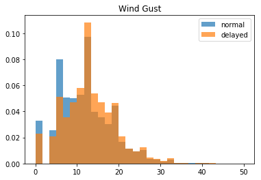

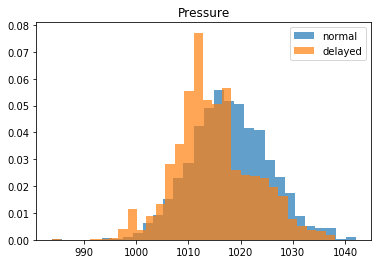

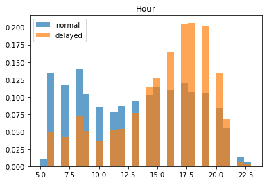

```python
# Anything unusual about these flights?
%matplotlib inline
import matplotlib.pyplot as plt
import seaborn as sns

plt.figure()
plt.hist(flights_weather.dropna().wind_gust, 30, range=(0, 50), normed=True, label='normal', alpha=.7)
plt.hist(flights_weather_posdelays.dropna().wind_gust, 30, range=(0,50), normed=True, label='delayed', alpha=.7)
plt.legend(loc='best')
plt.title('Wind Gust')

plt.figure()
plt.hist(flights_weather.dropna().pressure, 30,  normed=True, label='normal', alpha=.7)
plt.hist(flights_weather_posdelays.dropna().pressure, 30,  normed=True, label='delayed', alpha=.7)
plt.legend(loc='best')
plt.title('Pressure')

plt.figure()
plt.hist(flights_weather.dropna().hour, 30,  normed=True, label='normal', alpha=.7)
plt.hist(flights_weather_posdelays.dropna().hour, 30,  normed=True, label='delayed', alpha=.7)
plt.legend(loc='best')
plt.title('Hour')
```

## Capitalization issues.

```python
flights_complete['dest'].str.lower().head() # For string columns, use .str to access string methods
```

```
0    iah
1    iah
2    mia
3    bqn
4    atl
Name: dest, dtype: object
```

```python
flights_complete.dest.str.upper().head()
```

```
0    IAH
1    IAH
2    MIA
3    BQN
4    ATL
Name: dest, dtype: object
```

## Removing duplicates

```python
flights_complete = flights_complete.drop_duplicates('month', keep='first')
flights_complete
```

|  | year | month | day | dep_time | sched_dep_time | dep_delay | arr_time | sched_arr_time | arr_delay | carrier | flight | tailnum | origin | dest | air_time | distance | hour | minute | time_hour |
| --- | --- | --- | --- | --- | --- | --- | --- | --- | --- | --- | --- | --- | --- | --- | --- | --- | --- | --- | --- |
| 0 | 2013 | 1 | 1 | 517.0 | 515 | 2.0 | 830.0 | 819 | 11.0 | UA | 1545 | N14228 | EWR | IAH | 227.0 | 1400 | 5 | 15 | 2013-01-01 05:00:00 |
| 27004 | 2013 | 10 | 1 | 447.0 | 500 | -13.0 | 614.0 | 648 | -34.0 | US | 1877 | N538UW | EWR | CLT | 69.0 | 529 | 5 | 0 | 2013-10-01 05:00:00 |
| 55893 | 2013 | 11 | 1 | 5.0 | 2359 | 6.0 | 352.0 | 345 | 7.0 | B6 | 745 | N568JB | JFK | PSE | 205.0 | 1617 | 23 | 59 | 2013-11-01 23:00:00 |
| 83161 | 2013 | 12 | 1 | 13.0 | 2359 | 14.0 | 446.0 | 445 | 1.0 | B6 | 745 | N715JB | JFK | PSE | 195.0 | 1617 | 23 | 59 | 2013-12-01 23:00:00 |
| 111296 | 2013 | 2 | 1 | 456.0 | 500 | -4.0 | 652.0 | 648 | 4.0 | US | 1117 | N197UW | EWR | CLT | 98.0 | 529 | 5 | 0 | 2013-02-01 05:00:00 |
| 136247 | 2013 | 3 | 1 | 4.0 | 2159 | 125.0 | 318.0 | 56 | 142.0 | B6 | 11 | N706JB | JFK | FLL | 166.0 | 1069 | 21 | 59 | 2013-03-01 21:00:00 |
| 165081 | 2013 | 4 | 1 | 454.0 | 500 | -6.0 | 636.0 | 640 | -4.0 | US | 1843 | N566UW | EWR | CLT | 84.0 | 529 | 5 | 0 | 2013-04-01 05:00:00 |
| 193411 | 2013 | 5 | 1 | 9.0 | 1655 | 434.0 | 308.0 | 2020 | 408.0 | VX | 413 | N628VA | JFK | LAX | 341.0 | 2475 | 16 | 55 | 2013-05-01 16:00:00 |
| 222207 | 2013 | 6 | 1 | 2.0 | 2359 | 3.0 | 341.0 | 350 | -9.0 | B6 | 739 | N618JB | JFK | PSE | 200.0 | 1617 | 23 | 59 | 2013-06-01 23:00:00 |
| 250450 | 2013 | 7 | 1 | 1.0 | 2029 | 212.0 | 236.0 | 2359 | 157.0 | B6 | 915 | N653JB | JFK | SFO | 315.0 | 2586 | 20 | 29 | 2013-07-01 20:00:00 |
| 279875 | 2013 | 8 | 1 | 12.0 | 2130 | 162.0 | 257.0 | 14 | 163.0 | B6 | 1371 | N618JB | LGA | FLL | 149.0 | 1076 | 21 | 30 | 2013-08-01 21:00:00 |
| 309202 | 2013 | 9 | 1 | 9.0 | 2359 | 10.0 | 343.0 | 340 | 3.0 | B6 | 839 | N663JB | JFK | BQN | 196.0 | 1576 | 23 | 59 | 2013-09-01 23:00:00 |

## Writing to file

Pandas makes writing the results to a file very simple:

```python
# Write to a CSV (comma-seperated value) file

# top 20 rows
top = flights.head(20)
top.to_csv("flights_top.csv")

top.to_csv("flights_top.csv", sep="\t")  # Use tab as a separator instead of comma


top.to_excel("flights_top.xlsx", sheet_name='FlightsTop')  # Use tab as a separator instead of comma

# You might need to install the openpyxl module for Excel writing to work
# To do this, open a terminal and type in "conda install openpyxl", then restart the jupyter notebook by
# going to Kernel (at the top) and selecting 'Restart'.  You will have to re-run the earlier cells that load the data
```

# Plotting in Python

```
- Matplotlib
- Seaborn
- Other Popular Libraries
```

# Matplotlib

```python
import matplotlib.pyplot as plt
```

Kind of strange, but this is generally how matplotlib is imported.

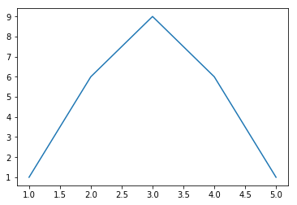

```python
# First plot
plt.figure()
x = [1, 2, 3, 4, 5]
y = [1, 6, 9, 6, 1]
plt.plot(x, y)
plt.show()
```

What is happening here:

- `plt.figure()`: Create a new figure
- `plt.plot(...)`: Add a plot to this figure
- `plot.show()`: Render the plot

In a terminal, `plot.show()` opens a new window. Code execution halts until you close the window.

If you use **ipython** though, you can run `%matplotlib` in order to enable interactive plotting.

In jupyter notebook - use `%matplotlib inline` or `%matplotlib notebook`

- No need for `plt.show` then. Any in-progress plots are shown at the end of a cell's execution automatically

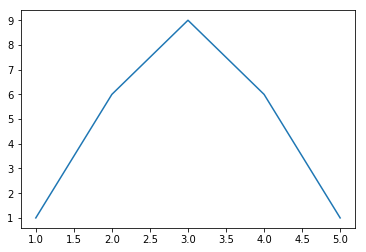

```python
%matplotlib inline
plt.figure()
plt.plot(x,y)
```

Why use `plt.figure`?

If you don't create a new figure explicitly, then plots are added to the existing figure.

- Unless there is no existing figure. Then one is just created

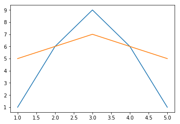

```python
plt.figure()
x = [1, 2, 3, 4, 5]
y = [1, 6, 9, 6, 1]
y2 = [5, 6, 7, 6, 5]
plt.plot(x,y)
plt.plot(x,y2)
```

Now, let's load some more interesting data

```python
import pandas as pd
airlines = pd.read_table("../data/nycflights13/airlines.txt")
airports = pd.read_table("../data/nycflights13/airports.txt")
flights = pd.read_table("../data/nycflights13/flights.txt")
planes = pd.read_table("../data/nycflights13/planes.txt")
weather = pd.read_table("../data/nycflights13/weather.txt")
```

Lets look at the weather table - this table contains information on the weather at each of the three origin airports for every hour of 2013.

```python
weather.head()
```

|  | origin | year | month | day | hour | temp | dewp | humid | wind_dir | wind_speed | wind_gust | precip | pressure | visib | time_hour |
| --- | --- | --- | --- | --- | --- | --- | --- | --- | --- | --- | --- | --- | --- | --- | --- |
| 0 | EWR | 2013 | 1 | 1 | 0 | 37.04 | 21.92 | 53.97 | 230.0 | 10.35702 | 11.918651 | 0.0 | 1013.9 | 10.0 | 2012-12-31 16:00:00 |
| 1 | EWR | 2013 | 1 | 1 | 1 | 37.04 | 21.92 | 53.97 | 230.0 | 13.80936 | 15.891535 | 0.0 | 1013.0 | 10.0 | 2012-12-31 17:00:00 |
| 2 | EWR | 2013 | 1 | 1 | 2 | 37.94 | 21.92 | 52.09 | 230.0 | 12.65858 | 14.567241 | 0.0 | 1012.6 | 10.0 | 2012-12-31 18:00:00 |
| 3 | EWR | 2013 | 1 | 1 | 3 | 37.94 | 23.00 | 54.51 | 230.0 | 13.80936 | 15.891535 | 0.0 | 1012.7 | 10.0 | 2012-12-31 19:00:00 |
| 4 | EWR | 2013 | 1 | 1 | 4 | 37.94 | 24.08 | 57.04 | 240.0 | 14.96014 | 17.215830 | 0.0 | 1012.8 | 10.0 | 2012-12-31 20:00:00 |

```python
# Let's get the total precipitation for each month
daily_precip = weather.groupby(['origin', 'month'])['precip'].sum().reset_index()
ewr_precip = daily_precip.loc[daily_precip.origin == 'EWR'].sort_values(['month']).precip.values
lga_precip = daily_precip.loc[daily_precip.origin == 'LGA'].sort_values(['month']).precip.values
jfk_precip = daily_precip.loc[daily_precip.origin == 'JFK'].sort_values(['month']).precip.values

print(ewr_precip)
```

```
[ 2.7   2.76  1.93  1.06  2.76  5.12  1.66  2.65  0.94  0.15  1.71  3.02]
```

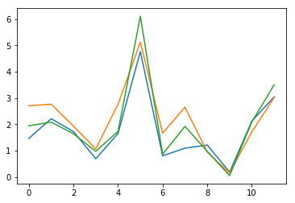

```python
# Let's add multiple line plots to the same axes
plt.figure()
plt.plot(lga_precip)
plt.plot(ewr_precip)
plt.plot(jfk_precip)
```

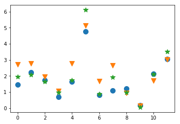

```python
# Let's change the style of them
plt.figure()
plt.plot(lga_precip, 'o', markersize=10)
plt.plot(ewr_precip, 'v', markersize=10)
plt.plot(jfk_precip, '*', markersize=10)
```

### Line/Marker styles in Matplotlib

There are 2 ways to set the style for the line and the points on the edges

1. Specify each property as its own argument in the plot function

   ```
   plt.plot(x, y,
            linestyle='solid', linewidth=10, color='blue',
            marker='o', markersize=5, markerfacecolor='green', markeredgecolor='red'
            )
   ```

2. Use an abbreviation ([documented here](https://matplotlib.org/api/pyplot_api.html#matplotlib.pyplot.plot))

   ```
   plt.plot(x, y, '-ob')  # Solid line, 'o' marker, blue
   ```

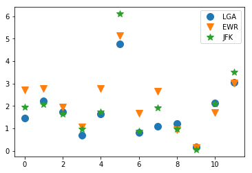

```python
# Let's add a legend
plt.figure()
plt.plot(lga_precip, 'o', markersize=10, label='LGA')
plt.plot(ewr_precip, 'v', markersize=10, label='EWR')
plt.plot(jfk_precip, '*', markersize=10, label='JFK')
plt.legend()
```

Let's add a bit more information to the plot

```
Text(0.5,1,'Precipitation Over Time')
```

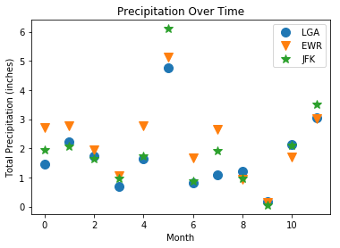

```python
plt.figure()
plt.plot(lga_precip, 'o', markersize=10, label='LGA')
plt.plot(ewr_precip, 'v', markersize=10, label='EWR')
plt.plot(jfk_precip, '*', markersize=10, label='JFK')
plt.legend()
plt.xlabel('Month')
plt.ylabel('Total Precipitation (inches)')
plt.title('Precipitation Over Time')
```

```python
# Easy to save to a variety for formats
plt.savefig('precipitation.pdf')
plt.savefig('precipitation.svg')
plt.savefig('precipitation.png')
```

### Scatter plots

Difference between scatter and plot

- Use scatter plots when you want every point to have a different size or color
- Let's see an example

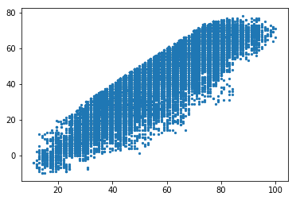

```python
# Like this, it's not too different from plt.plot with markersize=5
plt.figure()
plt.scatter(weather.temp, weather.dewp, s=5)
```

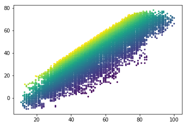

```python
plt.figure()
plt.scatter(weather['temp'], weather.dewp, c=weather.humid, s=5)
```

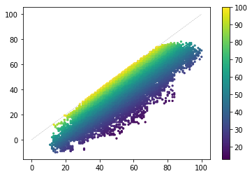

```python
# Let's add a x=y line and a colorbar
plt.figure()
plt.scatter(weather['temp'], weather.dewp, c=weather.humid, s=5)
plt.plot([0, 100], [0, 100], '--', color='#aaaaaa', linewidth=.5)
plt.colorbar()
```

**Here we can learn something about temperature, dewpoint, and humidity**

- Dewpoint is the temperature which water will condensate on an object
- It's linearly dependent on temperature, but there was still not a 1-1 mapping
- By adding color, we can see that humidity is the contributor to the difference between temperature and dewpoint

### Multiple plots in a figure - using subplot

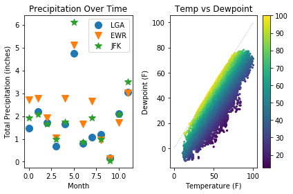

```python
plt.figure() # Create a new figure
plt.subplot(1, 2, 1) # 1 row, 2 columns, plot #1

plt.plot(lga_precip, 'o', markersize=10, label='LGA')
plt.plot(ewr_precip, 'v', markersize=10, label='EWR')
plt.plot(jfk_precip, '*', markersize=10, label='JFK')
plt.legend()
plt.xlabel('Month')
plt.ylabel('Total Precipitation (inches)')
plt.title('Precipitation Over Time')

plt.subplot(1, 2, 2) # 1 row, 2 columns, plot #2

plt.scatter(weather.temp, weather.dewp, c=weather.humid, s=5)
plt.plot([0, 100], [0, 100], '--', color='#aaaaaa', linewidth=.5)
plt.colorbar()
plt.xlabel('Temperature (F)')
plt.ylabel('Dewpoint (F)')
plt.title('Temp vs Dewpoint')
plt.tight_layout()
```

### Adjusting subplots

There are three ways to fix this

1. Give the plots more space to start with
   - When you call `plt.figure`, you can specify a figure size (inches x inches) (demo with 10x5)
2. Manually specify different spacings using `plt.subplots_adjust`
   - left = 0.125
     - the left side of the subplots of the figure
   - right = 0.9
     - the right side of the subplots of the figure
   - bottom = 0.1
     - the bottom of the subplots of the figure
   - top = 0.9
     - the top of the subplots of the figure
   - wspace = 0.2
     - the amount of width reserved for blank space between subplots, expressed as a fraction of the average axis width
   - hspace = 0.2
     - the amount of height reserved for white space between subplots, expressed as a fraction of the average axis height
3. Call `plt.tight_layout()` and let matplotlib figure it out

```python
plt.close('all') # Close all interactive plots currently open
```

### Histograms

Lets look at some histograms in matplotlib

To do this, we'll use some of the data in the 'flights' table

```python
flights.head()
```

|  | year | month | day | dep_time | sched_dep_time | dep_delay | arr_time | sched_arr_time | arr_delay | carrier | flight | tailnum | origin | dest | air_time | distance | hour | minute | time_hour |
| --- | --- | --- | --- | --- | --- | --- | --- | --- | --- | --- | --- | --- | --- | --- | --- | --- | --- | --- | --- |
| 0 | 2013 | 1 | 1 | 517.0 | 515 | 2.0 | 830.0 | 819 | 11.0 | UA | 1545 | N14228 | EWR | IAH | 227.0 | 1400 | 5 | 15 | 2013-01-01 05:00:00 |
| 1 | 2013 | 1 | 1 | 533.0 | 529 | 4.0 | 850.0 | 830 | 20.0 | UA | 1714 | N24211 | LGA | IAH | 227.0 | 1416 | 5 | 29 | 2013-01-01 05:00:00 |
| 2 | 2013 | 1 | 1 | 542.0 | 540 | 2.0 | 923.0 | 850 | 33.0 | AA | 1141 | N619AA | JFK | MIA | 160.0 | 1089 | 5 | 40 | 2013-01-01 05:00:00 |
| 3 | 2013 | 1 | 1 | 544.0 | 545 | -1.0 | 1004.0 | 1022 | -18.0 | B6 | 725 | N804JB | JFK | BQN | 183.0 | 1576 | 5 | 45 | 2013-01-01 05:00:00 |
| 4 | 2013 | 1 | 1 | 554.0 | 600 | -6.0 | 812.0 | 837 | -25.0 | DL | 461 | N668DN | LGA | ATL | 116.0 | 762 | 6 | 0 | 2013-01-01 06:00:00 |

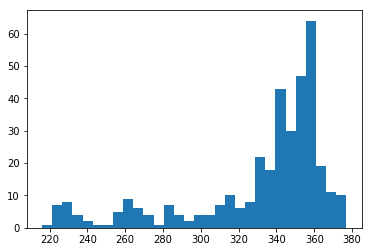

```python
daily_departures = (flights.groupby(['origin', 'year', 'month', 'day'])
    .size()
    .reset_index())

ewr_departures = daily_departures.loc[daily_departures.origin == 'EWR'][0]  # .size() put its result in column 0
plt.figure()
plt.hist(ewr_departures, bins=30);
```

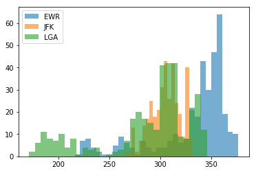

```python
# Add multiple histograms - use 'alpha' to overlay

jfk_departures = daily_departures.loc[daily_departures.origin == 'JFK'][0]  # .size() put its result in column 0
lga_departures = daily_departures.loc[daily_departures.origin == 'LGA'][0]  # .size() put its result in column 0
plt.figure()
plt.hist(ewr_departures, bins=30, label='EWR', alpha=.6)
plt.hist(jfk_departures, bins=30, label='JFK', alpha=.6)
plt.hist(lga_departures, bins=30, label='LGA', alpha=.6)
plt.legend()
```

### Alternate plot styles

You can use the command 'plt.styles.use' to change the plotting style

Matplotlib comes with several options built-in

```python
plt.style.available
```

```
['Solarize_Light2',
 '_classic_test',
 'bmh',
 'classic',
 'dark_background',
 'fast',
 'fivethirtyeight',
 'ggplot',
 'grayscale',
 'seaborn-bright',
 'seaborn-colorblind',
 'seaborn-dark-palette',
 'seaborn-dark',
 'seaborn-darkgrid',
 'seaborn-deep',
 'seaborn-muted',
 'seaborn-notebook',
 'seaborn-paper',
 'seaborn-pastel',
 'seaborn-poster',
 'seaborn-talk',
 'seaborn-ticks',
 'seaborn-white',
 'seaborn-whitegrid',
 'seaborn']
```

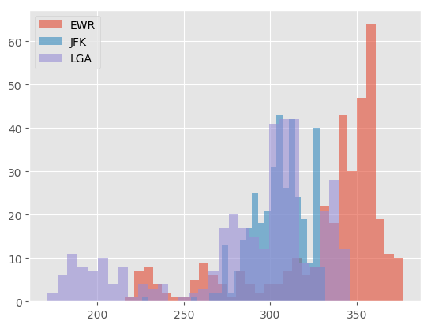

```python
plt.style.use('ggplot')
plt.figure()
plt.hist(ewr_departures, bins=30, label='EWR', alpha=.6)
plt.hist(jfk_departures, bins=30, label='JFK', alpha=.6)
plt.hist(lga_departures, bins=30, label='LGA', alpha=.6)
plt.legend(loc='best')
```

# Seaborn

Seaborn is a plotting library that is built on top of **matplotlib**

You can do anything in seaborn with just matplotlib commands. Seaborn just makes it much less tedious.

Seaborn is useful for:

- Heatmaps
- Statistical plots
- Dealing with Categorical variables

## Learning seaborn conventions with *jointplot*

`jointplot` is a handy function for plotting the joint distribution of two variables

```python
import seaborn as sns  # This is how seaborn is usually abbreviated
plt.style.use('default')
tips = sns.load_dataset('tips')
tips.head()
```

|  | total_bill | tip | sex | smoker | day | time | size |
| --- | --- | --- | --- | --- | --- | --- | --- |
| 0 | 16.99 | 1.01 | Female | No | Sun | Dinner | 2 |
| 1 | 10.34 | 1.66 | Male | No | Sun | Dinner | 3 |
| 2 | 21.01 | 3.50 | Male | No | Sun | Dinner | 3 |
| 3 | 23.68 | 3.31 | Male | No | Sun | Dinner | 2 |
| 4 | 24.59 | 3.61 | Female | No | Sun | Dinner | 4 |

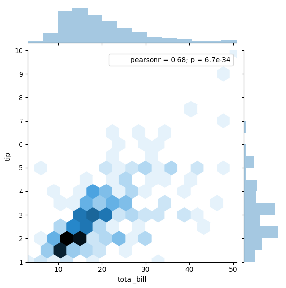

```python
#sns.jointplot(tips.total_bill, tips.tip)
sns.jointplot(tips.total_bill, tips.tip, kind='hex')
```

Here's our plot! Some things to notice:

- Seaborn has already filled in the x and y labels
- This is actually a matplotlib Figure. The figure has three Axes (subplots)
- If we zoom in, the histograms zoom to follow

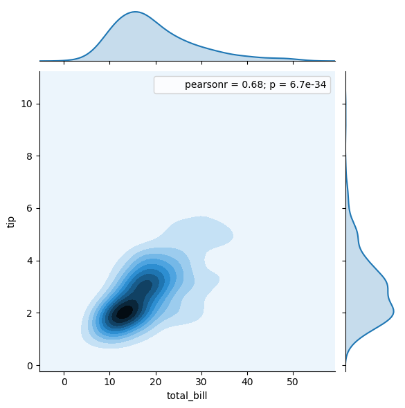

```python
sns.jointplot(x=tips.total_bill, y=tips.tip, kind='kde')
```

### DataFrames and Seaborn

Seaborn makes it easy to just use dataframes directly.

Recall that our 'tips' dataframe has columns 'total_bill' and 'tip'

All seaborn plotting functions provide an alternate way of calling them that uses the dataframe directly:

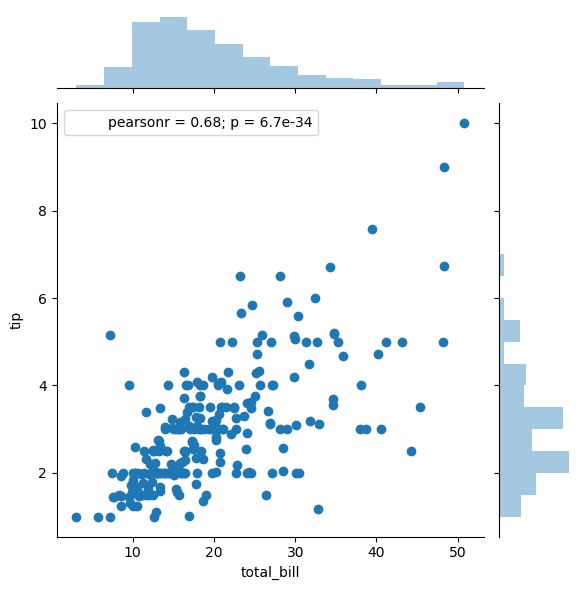

```python
# Use dataframe columns directly
sns.jointplot(x='total_bill', y='tip', data=tips)
```

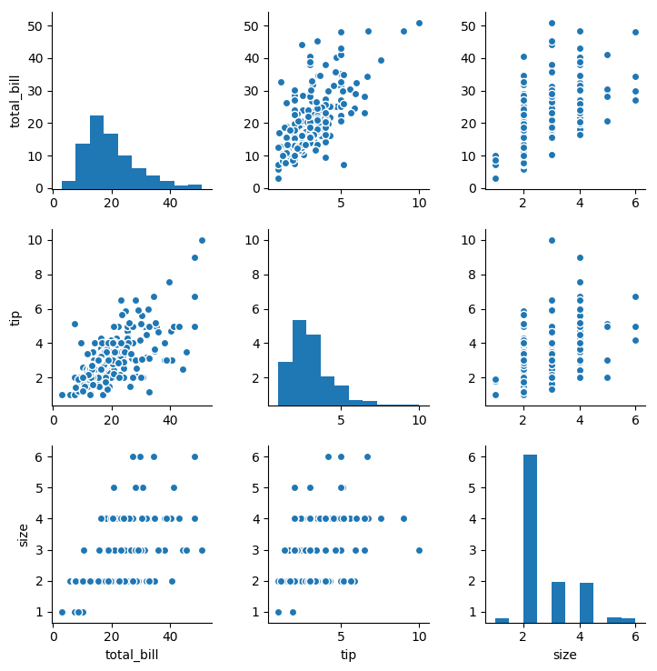

```python
# Pairplot
sns.pairplot(vars=['total_bill', 'tip', 'size'], data=tips)
```

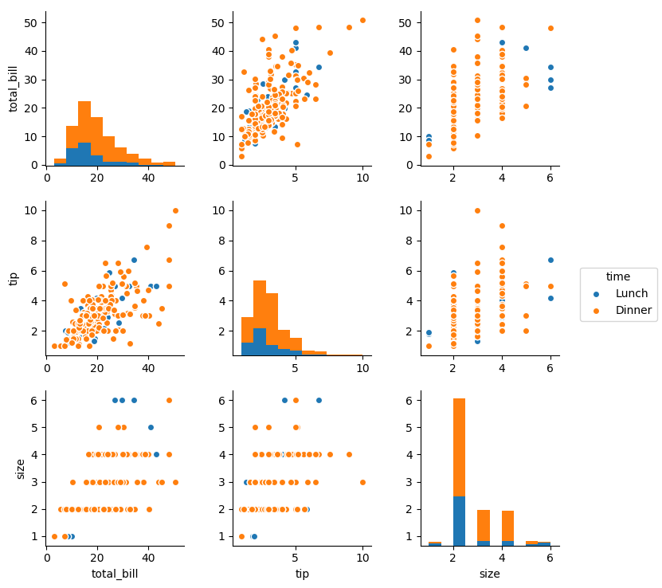

```python
# Pairplot - add hue
sns.pairplot(vars=['total_bill', 'tip', 'size'], hue='time', data=tips)
plt.subplots_adjust(right=.85)
```

### Box/violin

These are all plots for showing distributions

Let's use a new dataset for this one

```python
titanic = sns.load_dataset("titanic")
titanic.head()
```

|  | survived | pclass | sex | age | sibsp | parch | fare | embarked | class | who | adult_male | deck | embark_town | alive | alone |
| --- | --- | --- | --- | --- | --- | --- | --- | --- | --- | --- | --- | --- | --- | --- | --- |
| 0 | 0 | 3 | male | 22.0 | 1 | 0 | 7.2500 | S | Third | man | True | NaN | Southampton | no | False |
| 1 | 1 | 1 | female | 38.0 | 1 | 0 | 71.2833 | C | First | woman | False | C | Cherbourg | yes | False |
| 2 | 1 | 3 | female | 26.0 | 0 | 0 | 7.9250 | S | Third | woman | False | NaN | Southampton | yes | True |
| 3 | 1 | 1 | female | 35.0 | 1 | 0 | 53.1000 | S | First | woman | False | C | Southampton | yes | False |
| 4 | 0 | 3 | male | 35.0 | 0 | 0 | 8.0500 | S | Third | man | True | NaN | Southampton | no | True |

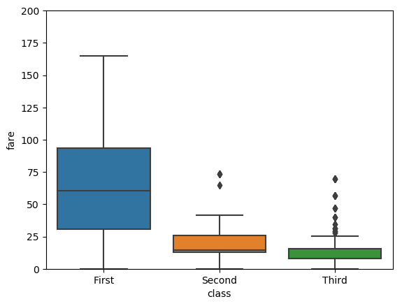

```python
plt.figure()
sns.boxplot(x='class', y='fare', data=titanic)
plt.ylim(0, 200);
```

```
(0, 160)
```

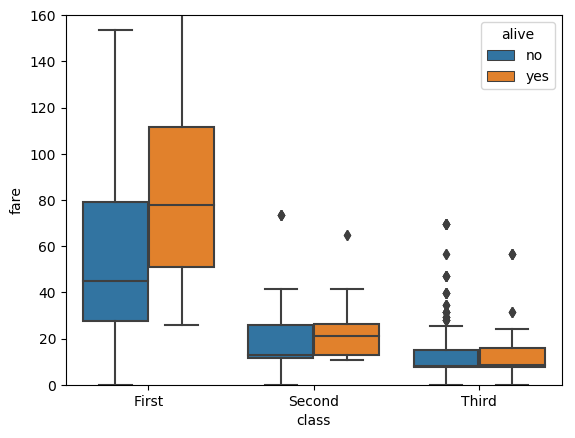

```python
plt.figure()
sns.boxplot(x='class', y='fare', hue='alive', data=titanic)
plt.ylim(0, 160)
```

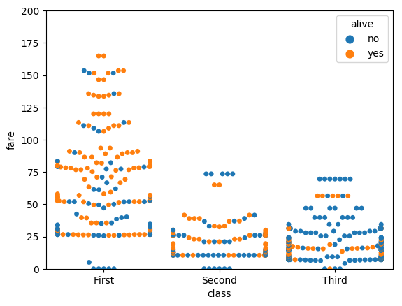

```python
plt.figure()
sns.swarmplot(x='class', y='fare', hue='alive', data=titanic)
plt.ylim(0, 200);
```

### Styles in Seaborn

One of seaborns early uses was just to get prettier matplotlib plots.

Matplotlib defaults were ugly, but if you just imported seaborn, they'd be set to something that looked nicer.

Now, matplotlib (2.0 and up) has decent looking defaults, but seaborn still has some nice options

- sns.set_style(*style_name*) can switch between plotting styles
  - *style_name* are 'white', 'dark', 'whitegrid', 'darkgrid', 'ticks'
- sns.despine() removes the top and right axes spines
- sns.set_context(*context_name*) will scale plot elements
  - *context_name* are 'talk', 'paper', 'notebook', 'poster'

```
(0, 160)
```

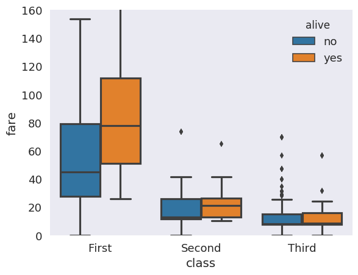

```python
sns.set_context('talk') # Make text bigger
sns.set_style("dark")
plt.figure()
sns.boxplot(x='class', y='fare', hue='alive', data=titanic)
plt.ylim(0, 160)
```

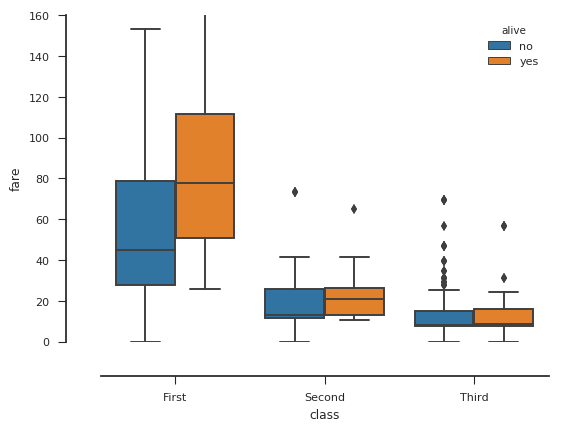

```python
sns.set_context('paper') # Make text bigger
sns.set_style("white")
sns.set_style("ticks")
plt.figure()
sns.boxplot(x='class', y='fare', hue='alive', data=titanic)
plt.ylim(0, 160)
plt.subplots_adjust(left=.2, bottom=.2)
sns.despine(offset=25)
```

```python
sns.set_context('notebook')
```

### Using *FaceGrid* to create plots for every level of a categorical variable

Let's visualize the distribution of the number of departures per day, in a separate plot for each month

```python
flights_per_day = flights.groupby(['origin', 'month', 'day']).size().reset_index()
flights_per_day.head()
```

|  | origin | month | day | 0 |
| --- | --- | --- | --- | --- |
| 0 | EWR | 1 | 1 | 305 |
| 1 | EWR | 1 | 2 | 350 |
| 2 | EWR | 1 | 3 | 336 |
| 3 | EWR | 1 | 4 | 339 |
| 4 | EWR | 1 | 5 | 238 |

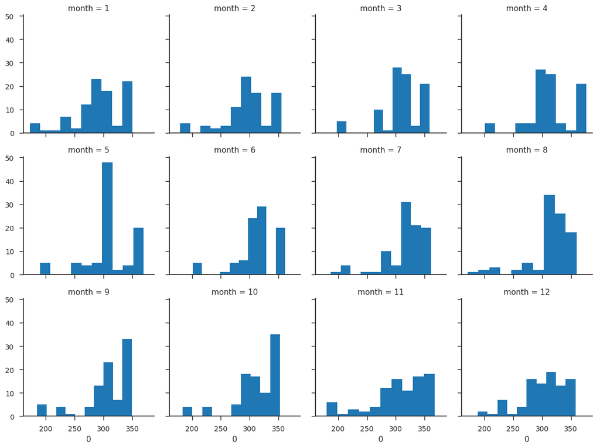

```python
plt.close('all')
g = sns.FacetGrid(data=flights_per_day, col='month', col_wrap=4)
g.map(plt.hist, 0)
```

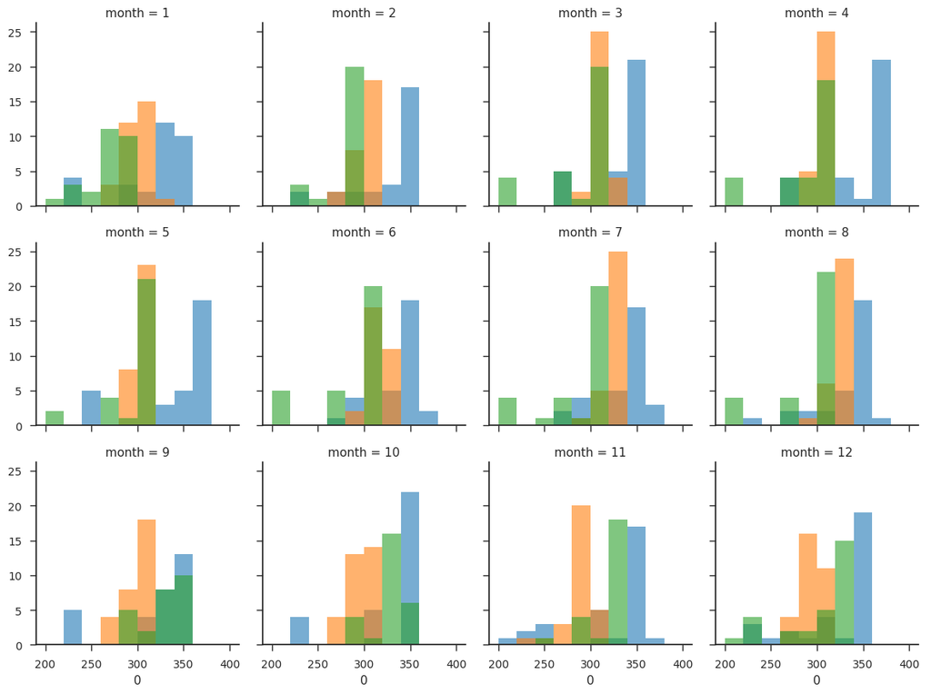

```python
# And we can add a hue (because why not?)
g = sns.FacetGrid(data=flights_per_day, col='month', col_wrap=4, hue='origin')
g.map(plt.hist, 0, range=(200, 400), alpha=.6)
```

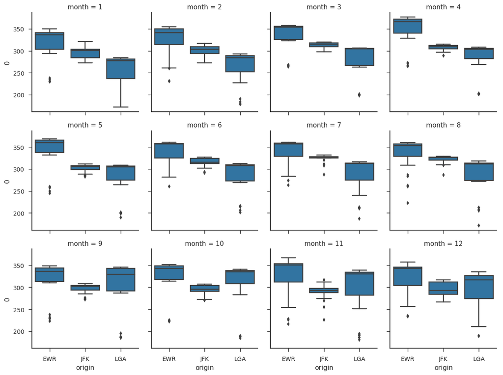

```python
# That's still a little hard to see, let's use box plots instead
g = sns.FacetGrid(data=flights_per_day, col='month', col_wrap=4)
g.map(sns.boxplot, "origin", 0)
```